# NBA Team Data Analysis

Conner Sparks

06/26/24

# Introduction

The purpose of this project is to practice techincal skills in R by working through some data cleaning exercises. Throughout this project, I will be using the tidyverse as much as possible.

**Note:**

**Throughout this document, any `season` column represents the year each season started. For example, the 2015-16 season will be in the dataset as 2015. For most of the rest of the project, we will refer to a season by just this number (e.g. 2015) instead of the full text (e.g. 2015-16).**

# Answers

## Part 1

**Question 1:**

- Offensive: 56.3% eFG
- Defensive: 47.86% eFG

**Question 2:** 64%

**Question 3:** 46%

**Question 4:** Written question. Answer is under Question 4.

**Question 5:** 83.02% of games

**Question 7:**

- Percent of +5.0 net rating teams making the 2nd round next year: 63.6%
- Percent of top 5 minutes played players who played in those 2nd round series: 78.1%

## Part 2

Work is shown in the document.

## Part 3

Work is shown in the document.

# Setup and Data

```r
library(tidyverse)
library(caret)
library(glmnet)

player_data <- read_csv("/Users/connersparks/Documents/playoffs_project_data/player_game_data.csv")
team_data <- read_csv("/Users/connersparks/Documents/playoffs_project_data/team_game_data.csv")
```

## Part 1 – Data Cleaning

Before answering any of these questions, I’ll take a look at the two data sets provided to see if there are any missing values or other cleaning steps that need to be taken.

```r
print(dim(team_data))
```

```
## [1] 27144    41
```

```r
team_data %>% is.na() %>% sum()
```

```
## [1] 0
```

The dimensions of team_data are 27,1444 x 41 and there are no missing values.

```r
team_data %>% summary()
```

```
##      season        gametype       nbagameid           gamedate
##  Min.   :2004   Min.   :2.000   Min.   :21400001   Min.   :2005-04-23
##  1st Qu.:2015   1st Qu.:2.000   1st Qu.:21600934   1st Qu.:2016-04-17
##  Median :2018   Median :2.000   Median :21900636   Median :2019-01-21
##  Mean   :2018   Mean   :2.235   Mean   :24131097   Mean   :2018-12-02
##  3rd Qu.:2021   3rd Qu.:2.000   3rd Qu.:22200660   3rd Qu.:2021-12-23
##  Max.   :2023   Max.   :4.000   Max.   :42200405   Max.   :2024-04-14
##  offensivenbateamid  off_team_name        off_team            off_home
##  Min.   :1.611e+09   Length:27144       Length:27144       Min.   :0.0
##  1st Qu.:1.611e+09   Class :character   Class :character   1st Qu.:0.0
##  Median :1.611e+09   Mode  :character   Mode  :character   Median :0.5
##  Mean   :1.611e+09                                         Mean   :0.5
##  3rd Qu.:1.611e+09                                         3rd Qu.:1.0
##  Max.   :1.611e+09                                         Max.   :1.0
##     off_win    defensivenbateamid  def_team_name        def_team
##  Min.   :0.0   Min.   :1.611e+09   Length:27144       Length:27144
##  1st Qu.:0.0   1st Qu.:1.611e+09   Class :character   Class :character
##  Median :0.5   Median :1.611e+09   Mode  :character   Mode  :character
##  Mean   :0.5   Mean   :1.611e+09
##  3rd Qu.:1.0   3rd Qu.:1.611e+09
##  Max.   :1.0   Max.   :1.611e+09
##     def_home      def_win       fg2made        fg2missed      fg2attempted
##  Min.   :0.0   Min.   :0.0   Min.   : 7.00   Min.   : 7.00   Min.   : 24.00
##  1st Qu.:0.0   1st Qu.:0.0   1st Qu.:25.00   1st Qu.:23.00   1st Qu.: 51.00
##  Median :0.5   Median :0.5   Median :29.00   Median :27.00   Median : 56.00
##  Mean   :0.5   Mean   :0.5   Mean   :29.06   Mean   :27.39   Mean   : 56.45
##  3rd Qu.:1.0   3rd Qu.:1.0   3rd Qu.:33.00   3rd Qu.:32.00   3rd Qu.: 62.00
##  Max.   :1.0   Max.   :1.0   Max.   :54.00   Max.   :72.00   Max.   :113.00
##     fg3made        fg3missed      fg3attempted       fgmade
##  Min.   : 0.00   Min.   : 1.00   Min.   : 4.00   Min.   :17.00
##  1st Qu.: 8.00   1st Qu.:15.00   1st Qu.:24.00   1st Qu.:36.00
##  Median :10.00   Median :19.00   Median :30.00   Median :40.00
##  Mean   :10.73   Mean   :19.25   Mean   :29.98   Mean   :39.79
##  3rd Qu.:13.00   3rd Qu.:23.00   3rd Qu.:36.00   3rd Qu.:43.00
##  Max.   :29.00   Max.   :47.00   Max.   :70.00   Max.   :65.00
##     fgmissed      fgattempted         ftmade         ftmissed
##  Min.   :23.00   Min.   : 51.00   Min.   : 0.00   Min.   : 0.000
##  1st Qu.:42.00   1st Qu.: 81.00   1st Qu.:13.00   1st Qu.: 3.000
##  Median :46.00   Median : 86.00   Median :17.00   Median : 5.000
##  Mean   :46.64   Mean   : 86.43   Mean   :17.57   Mean   : 5.273
```

[output cut: 15 more lines]

```
##  Max.   :22.000   Max.   :31   Max.   :20.000   Max.   :41.00
##  offensivefouls   shootingfoulsdrawn  possessions         points
##  Min.   : 0.000   Min.   : 0.000     Min.   : 76.00   Min.   : 61.0
##  1st Qu.: 1.000   1st Qu.: 8.000     1st Qu.: 94.00   1st Qu.: 99.0
##  Median : 2.000   Median :10.000     Median : 98.00   Median :108.0
##  Mean   : 1.803   Mean   : 9.826     Mean   : 97.66   Mean   :107.9
##  3rd Qu.: 3.000   3rd Qu.:12.000     3rd Qu.:101.00   3rd Qu.:117.0
##  Max.   :10.000   Max.   :25.000     Max.   :142.00   Max.   :176.0
##   shotattempts       andones       shotattemptpoints
##  Min.   : 62.00   Min.   : 0.000   Min.   : 48.0
##  1st Qu.: 89.00   1st Qu.: 1.000   1st Qu.: 95.0
##  Median : 94.00   Median : 2.000   Median :104.0
##  Mean   : 93.92   Mean   : 2.265   Mean   :103.7
##  3rd Qu.: 99.00   3rd Qu.: 3.000   3rd Qu.:113.0
##  Max.   :139.00   Max.   :12.000   Max.   :174.0
```

Everything looks good in the summary as well. There are a number of identifier columns to specify game and season information, some binary columns, and various statistics about the teams’ performances in each game.

Now I’ll look at `player_data`.

```r
print(dim(player_data))
```

```
## [1] 434797     59
```

```r
player_data %>% is.na() %>% sum()
```

```
## [1] 4
```

Looks like there are a few missing values. With dimensions of 434,797 x 59, just 4 missing values in our data isn’t concerning. I’ll summarize the data and try to find where those could be coming from.

```r
player_data_na_rows <-
  player_data %>%
    filter(rowSums(is.na(player_data)) > 0)
player_data_na_rows
```

```
## # A tibble: 4 × 59
##   nbagameid gamedate   season gametype nbapersonid player_name  nbateamid team
##       <dbl> <date>      <dbl>    <dbl>       <dbl> <chr>            <dbl> <chr>
## 1  40900131 2010-04-17   2009        4     3216458 <NA>        1610612738 BOS
## 2  21400621 2015-01-19   2014        2      203296 <NA>        1610612758 SAC
## 3  21500512 2016-01-04   2015        2        6274 <NA>        1610612755 PHI
## 4  21701147 2018-04-01   2017        2  1962937848 <NA>        1610612737 ATL
## # ℹ 51 more variables: team_name <chr>, opposingnbateamid <dbl>,
## #   opp_team <chr>, opp_team_name <chr>, starter <dbl>, missed <dbl>,
## #   seconds <dbl>, points <dbl>, fg2made <dbl>, fg2missed <dbl>,
## #   fg2attempted <dbl>, fg3made <dbl>, fg3missed <dbl>, fg3attempted <dbl>,
## #   fgmade <dbl>, fgmissed <dbl>, fgattempted <dbl>, ftmade <dbl>,
## #   ftmissed <dbl>, ftattempted <dbl>, reboffensive <dbl>, rebdefensive <dbl>,
## #   offensivereboundchances <dbl>, defensivereboundchances <dbl>, …
```

Looks like there are 4 missing names in the data set. These rows have a value in the `nbapersonid` column though, so maybe we can find who each id belongs to and fill in these missing names.

```r
na_player_ids <- player_data_na_rows %>% pull(nbapersonid)
na_player_rows <- player_data %>% filter(nbapersonid %in% na_player_ids)
print(na_player_rows)
```

```
## # A tibble: 4 × 59
##   nbagameid gamedate   season gametype nbapersonid player_name  nbateamid team
##       <dbl> <date>      <dbl>    <dbl>       <dbl> <chr>            <dbl> <chr>
## 1  40900131 2010-04-17   2009        4     3216458 <NA>        1610612738 BOS
## 2  21400621 2015-01-19   2014        2      203296 <NA>        1610612758 SAC
## 3  21500512 2016-01-04   2015        2        6274 <NA>        1610612755 PHI
## 4  21701147 2018-04-01   2017        2  1962937848 <NA>        1610612737 ATL
## # ℹ 51 more variables: team_name <chr>, opposingnbateamid <dbl>,
## #   opp_team <chr>, opp_team_name <chr>, starter <dbl>, missed <dbl>,
## #   seconds <dbl>, points <dbl>, fg2made <dbl>, fg2missed <dbl>,
## #   fg2attempted <dbl>, fg3made <dbl>, fg3missed <dbl>, fg3attempted <dbl>,
## #   fgmade <dbl>, fgmissed <dbl>, fgattempted <dbl>, ftmade <dbl>,
## #   ftmissed <dbl>, ftattempted <dbl>, reboffensive <dbl>, rebdefensive <dbl>,
## #   offensivereboundchances <dbl>, defensivereboundchances <dbl>, …
```

It seems like those 4 players didn’t play in any other games. It also looks like they didn’t play in these games. We should be able to drop these rows in the future if we need to, without any concerns.

Finally, I’ll summarize the `player_data` data set and see what I’ll be working with.

```r
player_data %>% summary()
```

```
##    nbagameid           gamedate              season        gametype
##  Min.   :21400001   Min.   :2005-04-23   Min.   :2004   Min.   :2.000
##  1st Qu.:21601201   1st Qu.:2016-11-25   1st Qu.:2016   1st Qu.:2.000
##  Median :21900801   Median :2019-03-13   Median :2018   Median :2.000
##  Mean   :23966780   Mean   :2019-02-19   Mean   :2018   Mean   :2.216
##  3rd Qu.:22200679   3rd Qu.:2022-01-17   3rd Qu.:2021   3rd Qu.:2.000
##  Max.   :42200405   Max.   :2024-04-14   Max.   :2023   Max.   :4.000
##   nbapersonid        player_name          nbateamid             team
##  Min.   :1.500e+01   Length:434797      Min.   :1.611e+09   Length:434797
##  1st Qu.:2.021e+05   Class :character   1st Qu.:1.611e+09   Class :character
##  Median :2.039e+05   Mode  :character   Median :1.611e+09   Mode  :character
##  Mean   :8.410e+05                      Mean   :1.611e+09
##  3rd Qu.:1.629e+06                      3rd Qu.:1.611e+09
##  Max.   :1.963e+09                      Max.   :1.611e+09
##   team_name         opposingnbateamid     opp_team         opp_team_name
##  Length:434797      Min.   :1.611e+09   Length:434797      Length:434797
##  Class :character   1st Qu.:1.611e+09   Class :character   Class :character
##  Mode  :character   Median :1.611e+09   Mode  :character   Mode  :character
##                     Mean   :1.611e+09
##                     3rd Qu.:1.611e+09
##                     Max.   :1.611e+09
##     starter           missed          seconds           points
##  Min.   :0.0000   Min.   :0.0000   Min.   :   0.0   Min.   : 0.000
##  1st Qu.:0.0000   1st Qu.:0.0000   1st Qu.:   0.0   1st Qu.: 0.000
##  Median :0.0000   Median :0.0000   Median : 882.0   Median : 3.000
##  Mean   :0.3121   Mean   :0.1522   Mean   : 904.4   Mean   : 6.735
##  3rd Qu.:1.0000   3rd Qu.:0.0000   3rd Qu.:1649.0   3rd Qu.:11.000
##  Max.   :1.0000   Max.   :1.0000   Max.   :3895.3   Max.   :73.000
##     fg2made         fg2missed      fg2attempted       fg3made
##  Min.   : 0.000   Min.   : 0.00   Min.   : 0.000   Min.   : 0.00
##  1st Qu.: 0.000   1st Qu.: 0.00   1st Qu.: 0.000   1st Qu.: 0.00
##  Median : 1.000   Median : 1.00   Median : 2.000   Median : 0.00
##  Mean   : 1.814   Mean   : 1.71   Mean   : 3.524   Mean   : 0.67
##  3rd Qu.: 3.000   3rd Qu.: 3.00   3rd Qu.: 6.000   3rd Qu.: 1.00
##  Max.   :23.000   Max.   :21.00   Max.   :39.000   Max.   :14.00
##    fg3missed       fg3attempted        fgmade          fgmissed
##  Min.   : 0.000   Min.   : 0.000   Min.   : 0.000   Min.   : 0.000
##  1st Qu.: 0.000   1st Qu.: 0.000   1st Qu.: 0.000   1st Qu.: 0.000
##  Median : 0.000   Median : 0.000   Median : 1.000   Median : 2.000
##  Mean   : 1.202   Mean   : 1.872   Mean   : 2.484   Mean   : 2.911
```

[output cut: 57 more lines]

```
##  Max.   :146.00   Max.   :142.00     Max.   :127.00   Max.   :55.00
##  teamfgattempted  teamturnovers    opponentteamfg2attempted
##  Min.   :  0.00   Min.   : 0.000   Min.   : 0.00
##  1st Qu.:  0.00   1st Qu.: 0.000   1st Qu.: 0.00
##  Median : 26.00   Median : 4.000   Median :16.00
##  Mean   : 26.98   Mean   : 4.371   Mean   :17.62
##  3rd Qu.: 49.00   3rd Qu.: 8.000   3rd Qu.:32.00
##  Max.   :117.00   Max.   :27.000   Max.   :96.00
##  opponentteamfg3attempted
##  Min.   : 0.000
##  1st Qu.: 0.000
##  Median : 8.000
##  Mean   : 9.358
##  3rd Qu.:16.000
##  Max.   :61.000
```

### Question 1

**QUESTION:** I will find the Warriors’ Team offensive and defensive eFG% in the 2015-16 regular season. This is in the data as the 2015 season.

First, because we are interested in the regular season eFG%, I will filter out any preseason or postseason games in our data. I will also grab data on only the Golden State Warriors (GSW) by filtering out all other NBA teams.

```r
GSW_2015_reg_season <- team_data %>% filter(season == 2015, off_team == "GSW" | def_team == "GSW", gametype == 2)
GSW_2015_reg_season
```

```
## # A tibble: 164 × 41
##    season gametype nbagameid gamedate   offensivenbateamid off_team_name
##     <dbl>    <dbl>     <dbl> <date>                  <dbl> <chr>
##  1   2015        2  21501112 2016-03-29         1610612744 Golden State Warriors
##  2   2015        2  21501112 2016-03-29         1610612764 Washington Wizards
##  3   2015        2  21500290 2015-12-05         1610612744 Golden State Warriors
##  4   2015        2  21500290 2015-12-05         1610612761 Toronto Raptors
##  5   2015        2  21500592 2016-01-14         1610612744 Golden State Warriors
##  6   2015        2  21500592 2016-01-14         1610612747 Los Angeles Lakers
##  7   2015        2  21500003 2015-10-27         1610612740 New Orleans Pelicans
##  8   2015        2  21500003 2015-10-27         1610612744 Golden State Warriors
##  9   2015        2  21501177 2016-04-07         1610612744 Golden State Warriors
## 10   2015        2  21501177 2016-04-07         1610612759 San Antonio Spurs
## # ℹ 154 more rows
## # ℹ 35 more variables: off_team <chr>, off_home <dbl>, off_win <dbl>,
## #   defensivenbateamid <dbl>, def_team_name <chr>, def_team <chr>,
## #   def_home <dbl>, def_win <dbl>, fg2made <dbl>, fg2missed <dbl>,
## #   fg2attempted <dbl>, fg3made <dbl>, fg3missed <dbl>, fg3attempted <dbl>,
## #   fgmade <dbl>, fgmissed <dbl>, fgattempted <dbl>, ftmade <dbl>,
## #   ftmissed <dbl>, ftattempted <dbl>, reboffensive <dbl>, …
```

Because we are interested in both offensive and defensive eFG%, I will separate the data into two variables.

```r
# Grabbing GSW's offensive/defensive team data from the 2015 season.
GSW_2015_off <- GSW_2015_reg_season %>% filter(off_team == "GSW")
GSW_2015_def <- GSW_2015_reg_season %>% filter(def_team == "GSW")

GSW_2015_off
```

```
## # A tibble: 82 × 41
##    season gametype nbagameid gamedate   offensivenbateamid off_team_name
##     <dbl>    <dbl>     <dbl> <date>                  <dbl> <chr>
##  1   2015        2  21501112 2016-03-29         1610612744 Golden State Warriors
##  2   2015        2  21500290 2015-12-05         1610612744 Golden State Warriors
##  3   2015        2  21500592 2016-01-14         1610612744 Golden State Warriors
##  4   2015        2  21500003 2015-10-27         1610612744 Golden State Warriors
##  5   2015        2  21501177 2016-04-07         1610612744 Golden State Warriors
##  6   2015        2  21501050 2016-03-21         1610612744 Golden State Warriors
##  7   2015        2  21500187 2015-11-20         1610612744 Golden State Warriors
##  8   2015        2  21500092 2015-11-07         1610612744 Golden State Warriors
##  9   2015        2  21500485 2015-12-31         1610612744 Golden State Warriors
## 10   2015        2  21500381 2015-12-16         1610612744 Golden State Warriors
## # ℹ 72 more rows
## # ℹ 35 more variables: off_team <chr>, off_home <dbl>, off_win <dbl>,
## #   defensivenbateamid <dbl>, def_team_name <chr>, def_team <chr>,
## #   def_home <dbl>, def_win <dbl>, fg2made <dbl>, fg2missed <dbl>,
## #   fg2attempted <dbl>, fg3made <dbl>, fg3missed <dbl>, fg3attempted <dbl>,
## #   fgmade <dbl>, fgmissed <dbl>, fgattempted <dbl>, ftmade <dbl>,
## #   ftmissed <dbl>, ftattempted <dbl>, reboffensive <dbl>, …
```

```r
GSW_2015_def
```

```
## # A tibble: 82 × 41
##    season gametype nbagameid gamedate   offensivenbateamid off_team_name
##     <dbl>    <dbl>     <dbl> <date>                  <dbl> <chr>
##  1   2015        2  21501112 2016-03-29         1610612764 Washington Wizards
##  2   2015        2  21500290 2015-12-05         1610612761 Toronto Raptors
##  3   2015        2  21500592 2016-01-14         1610612747 Los Angeles Lakers
##  4   2015        2  21500003 2015-10-27         1610612740 New Orleans Pelicans
##  5   2015        2  21501177 2016-04-07         1610612759 San Antonio Spurs
##  6   2015        2  21501050 2016-03-21         1610612750 Minnesota Timberwolv…
##  7   2015        2  21500187 2015-11-20         1610612741 Chicago Bulls
##  8   2015        2  21500092 2015-11-07         1610612758 Sacramento Kings
##  9   2015        2  21500485 2015-12-31         1610612745 Houston Rockets
## 10   2015        2  21500381 2015-12-16         1610612756 Phoenix Suns
## # ℹ 72 more rows
## # ℹ 35 more variables: off_team <chr>, off_home <dbl>, off_win <dbl>,
## #   defensivenbateamid <dbl>, def_team_name <chr>, def_team <chr>,
## #   def_home <dbl>, def_win <dbl>, fg2made <dbl>, fg2missed <dbl>,
## #   fg2attempted <dbl>, fg3made <dbl>, fg3missed <dbl>, fg3attempted <dbl>,
## #   fgmade <dbl>, fgmissed <dbl>, fgattempted <dbl>, ftmade <dbl>,
## #   ftmissed <dbl>, ftattempted <dbl>, reboffensive <dbl>, …
```

With the team data on the GSW’s 2015 season isolated, we can select our columns of interest. To calculate eFG%, we will need the team’s total two point field goals made (fg2made), their total three point field goals made (fg3made), and their total field goal attempts (fgattempted).

eFG% can be calculated in several ways.

- eFG% = (FG + (0.5 * 3P)) / FGA
  - According to Wikipedia, a criticism of this formula is that “that shooters with very high percentage success rates, which favor 3 point shots, would arrive at an eFG% above 100%”
- eFG% = ((PPG - FT) / 2) / FGA
- eFG% = (2FG + (1.5 * 3FG)) / FGA
  - Also according to Wikipedia, this formula seems to be the most widely used on websites displaying NBA statistics, so I will use it here.

```r
GSW_2015_off_total_2FG <- sum(GSW_2015_off$fg2made)
GSW_2015_off_total_3FG <- sum(GSW_2015_off$fg3made)
GSW_2015_off_total_FGA <- sum(GSW_2015_off$fgattempted)

GSW_2015_def_total_2FG <- sum(GSW_2015_def$fg2made)
GSW_2015_def_total_3FG <- sum(GSW_2015_def$fg3made)
GSW_2015_def_total_FGA <- sum(GSW_2015_def$fgattempted)
```

Now that we have our aggregates, we can calculate our eFG% for the GSW’s offense and defense.

```r
# Offensive eFG% rounded to 2 decimal places
GSW_2015_off_eFG <- round(100 * (GSW_2015_off_total_2FG + (1.5 * GSW_2015_off_total_3FG)) / (GSW_2015_off_total_FGA), 2)

# Defensive eFG% rounded to 2 decimal places
GSW_2015_def_eFG <- round(100 * (GSW_2015_def_total_2FG + (1.5 * GSW_2015_def_total_3FG)) / (GSW_2015_def_total_FGA), 2)
```

**ANSWER 1:**

Offensive: 56.3% eFG  
Defensive: 47.86% eFG

### Question 2

**QUESTION:** What percent of the time does the team with the higher eFG% in a given game win that game? I will use games from the 2014-2023 regular seasons. If two teams have an exactly equal eFG%, I will remove them from the calculation.

I will first grab regular season data during the years of interest with filtering.

```r
team_data_reg_season_2014_through_2023 <- team_data %>% filter(gametype == 2, season >= 2014)
team_data_reg_season_2014_through_2023
```

```
## # A tibble: 23,958 × 41
##    season gametype nbagameid gamedate   offensivenbateamid off_team_name
##     <dbl>    <dbl>     <dbl> <date>                  <dbl> <chr>
##  1   2016        2  21600495 2016-12-30         1610612740 New Orleans Pelicans
##  2   2016        2  21600495 2016-12-30         1610612752 New York Knicks
##  3   2021        2  22100943 2022-03-03         1610612742 Dallas Mavericks
##  4   2021        2  22100943 2022-03-03         1610612744 Golden State Warriors
##  5   2016        2  21601032 2017-03-18         1610612741 Chicago Bulls
##  6   2016        2  21601032 2017-03-18         1610612762 Utah Jazz
##  7   2021        2  22100942 2022-03-03         1610612761 Toronto Raptors
##  8   2022        2  22200482 2022-12-23         1610612750 Minnesota Timberwolv…
##  9   2016        2  21600494 2016-12-30         1610612738 Boston Celtics
## 10   2016        2  21600494 2016-12-30         1610612748 Miami Heat
## # ℹ 23,948 more rows
## # ℹ 35 more variables: off_team <chr>, off_home <dbl>, off_win <dbl>,
## #   defensivenbateamid <dbl>, def_team_name <chr>, def_team <chr>,
## #   def_home <dbl>, def_win <dbl>, fg2made <dbl>, fg2missed <dbl>,
## #   fg2attempted <dbl>, fg3made <dbl>, fg3missed <dbl>, fg3attempted <dbl>,
## #   fgmade <dbl>, fgmissed <dbl>, fgattempted <dbl>, ftmade <dbl>,
## #   ftmissed <dbl>, ftattempted <dbl>, reboffensive <dbl>, …
```

There are a lot of columns within this data set that are unnecessary for the question we are interested in answering here. I will take care of that next.

With `nbagameid` as a unique identifier with two rows per unique ID, the offensive statistics of interest for this question are split across two rows. For convenience, I will group by `nbagameid` and select the `fg2made`, `fg3made`, and `fgattempted` values for each each of the two teams in each game. These 3 values will be labeled with off/def prefixes to indicate which values belong to which team. This will make it easy to calculate the eFG% of each team in each game, and will enhance readability.

```r
grouped_team_data_q2 <-
  team_data_reg_season_2014_through_2023 %>%
  group_by(nbagameid) %>%
  summarize(
    off_team = first(off_team_name),
    def_team = first(def_team_name),
    off_win = first(off_win),
    def_win = first(def_win),
    off_team_fg2made = first(fg2made),
    off_team_fg3made = first(fg3made),
    off_team_fgattempted = first(fgattempted),
    def_team_fg2made = last(fg2made),
    def_team_fg3made = last(fg3made),
    def_team_fgattempted = last(fgattempted)
  )
grouped_team_data_q2
```

```
## # A tibble: 11,979 × 11
##    nbagameid off_team def_team off_win def_win off_team_fg2made off_team_fg3made
##        <dbl> <chr>    <chr>      <dbl>   <dbl>            <dbl>            <dbl>
##  1  21400001 New Orl… Orlando…       1       0               37                4
##  2  21400002 Dallas … San Ant…       0       1               30                8
##  3  21400003 Houston… Los Ang…       1       0               19               12
##  4  21400004 Milwauk… Charlot…       0       1               32                7
##  5  21400005 Indiana… Philade…       1       0               30                8
##  6  21400006 Boston … Brookly…       1       0               41                8
##  7  21400007 Miami H… Washing…       1       0               30                9
##  8  21400008 Atlanta… Toronto…       0       1               27               13
##  9  21400009 Minneso… Memphis…       0       1               33                6
## 10  21400010 Chicago… New Yor…       1       0               29                7
## # ℹ 11,969 more rows
## # ℹ 4 more variables: off_team_fgattempted <dbl>, def_team_fg2made <dbl>,
## #   def_team_fg3made <dbl>, def_team_fgattempted <dbl>
```

This looks correct, but lets double check some of the rows to ensure the correct offensive scoring data was selected for each team.

I’ll grab `nbagameid` 21400001 (Pelicans v. Magic) from the `team_data_reg_season_2014_through_2023` tibble and look at our columns of interest. We’ll compare the values in those column to the values in the first row of the tibble above.

```r
team_data_reg_season_2014_through_2023 %>%
  filter(nbagameid == 21400001) %>%
  select(nbagameid, off_team_name, def_team_name, off_win, def_win, fg2made, fg3made, fgattempted)
```

```
## # A tibble: 2 × 8
##   nbagameid off_team_name        def_team_name   off_win def_win fg2made fg3made
##       <dbl> <chr>                <chr>             <dbl>   <dbl>   <dbl>   <dbl>
## 1  21400001 New Orleans Pelicans Orlando Magic         1       0      37       4
## 2  21400001 Orlando Magic        New Orleans Pe…       0       1      28       4
## # ℹ 1 more variable: fgattempted <dbl>
```

It looks like the Pelicans won this game with 37 made two pointers, 4 three pointers, and attempted 101 shots. The Magic made 28 two pointers, 4 three pointers, and attempted 84 shots. I’ll now grab this game from our `grouped_team_data_q2` tibble to make sure everything is where we expect it to be.

```r
pelicans_v_magic_check_q2 <- grouped_team_data_q2 %>% filter(nbagameid  == 21400001)

off_team_check_q2 <- pelicans_v_magic_check_q2 %>% select(off_team)
def_team_check_q2 <- pelicans_v_magic_check_q2 %>% select(def_team)

off_team_fg2made_check <- pelicans_v_magic_check_q2 %>% select(off_team_fg2made)
off_team_fg3made_check <- pelicans_v_magic_check_q2 %>% select(off_team_fg3made)
off_team_fgattempted_check <- pelicans_v_magic_check_q2 %>% select(off_team_fgattempted)

def_team_fg2made_check <- pelicans_v_magic_check_q2 %>% select(def_team_fg2made)
def_team_fg3made_check <- pelicans_v_magic_check_q2 %>% select(def_team_fg3made)
def_team_fgattempted_check <- pelicans_v_magic_check_q2 %>% select(def_team_fgattempted)

sprintf("off_team: %s", off_team_check_q2)
```

```
## [1] "off_team: New Orleans Pelicans"
```

```r
sprintf("off_team_fg2made: %s", off_team_fg2made_check)
```

```
## [1] "off_team_fg2made: 37"
```

```r
sprintf("off_team_fg3made: %s", off_team_fg3made_check)
```

```
## [1] "off_team_fg3made: 4"
```

```r
sprintf("off_team_fgattempted: %s", off_team_fgattempted_check)
```

```
## [1] "off_team_fgattempted: 101"
```

```r
cat("\n")
```

```r
sprintf("def_team: %s", def_team_check_q2)
```

```
## [1] "def_team: Orlando Magic"
```

```r
sprintf("def_team_fg2made: %s", def_team_fg2made_check)
```

```
## [1] "def_team_fg2made: 28"
```

```r
sprintf("def_team_fg3made: %s", def_team_fg3made_check)
```

```
## [1] "def_team_fg3made: 4"
```

```r
sprintf("def_team_fgattempted: %s", def_team_fgattempted_check)
```

```
## [1] "def_team_fgattempted: 84"
```

Comparing this output to the respective `fg2made`, `fg3made`, and `fgattempted` values in the selected rows above, everything looks good!

Now, we can look at a single row and see the name of the off/def team as well as the offensive statistics for each team in that game. These off/def labels help us to determine which of the following off/def `fg2made`/`fg3made`/`fgattempted` values belong to which team. I’ve also included the `off_win` and `def_win` columns so that after finding each team’s eFG%, we can easily find how often the team with the higher eFG% actually won.

I’ll now find the eFG% for the off/def team in each game.

```r
efg_per_game <-
  grouped_team_data_q2 %>%
    mutate(off_efg = round((100 * off_team_fg2made + (1.5 * off_team_fg3made)) / (off_team_fgattempted), 2)) %>%
    mutate(def_efg = round((100 * def_team_fg2made + (1.5 * def_team_fg3made)) / (def_team_fgattempted), 2))
efg_per_game
```

```
## # A tibble: 11,979 × 13
##    nbagameid off_team def_team off_win def_win off_team_fg2made off_team_fg3made
##        <dbl> <chr>    <chr>      <dbl>   <dbl>            <dbl>            <dbl>
##  1  21400001 New Orl… Orlando…       1       0               37                4
##  2  21400002 Dallas … San Ant…       0       1               30                8
##  3  21400003 Houston… Los Ang…       1       0               19               12
##  4  21400004 Milwauk… Charlot…       0       1               32                7
##  5  21400005 Indiana… Philade…       1       0               30                8
##  6  21400006 Boston … Brookly…       1       0               41                8
##  7  21400007 Miami H… Washing…       1       0               30                9
##  8  21400008 Atlanta… Toronto…       0       1               27               13
##  9  21400009 Minneso… Memphis…       0       1               33                6
## 10  21400010 Chicago… New Yor…       1       0               29                7
## # ℹ 11,969 more rows
## # ℹ 6 more variables: off_team_fgattempted <dbl>, def_team_fg2made <dbl>,
## #   def_team_fg3made <dbl>, def_team_fgattempted <dbl>, off_efg <dbl>,
## #   def_efg <dbl>
```

Now that we’ve got the eFG% for each team calculated, we can easily find the percent of the time the team with the higher eFG% actually wins their game.

To do that, I’ll create a binary column called `higher_efg_won`. This column will have a value of 1 if the the team with the higher eFG% won, and a value of 0 otherwise. Then I can simply take the mean of this column to find our desired statistic.

```r
binary_higher_efg_won <-
  efg_per_game %>%
    select(off_win, def_win, off_efg, def_efg) %>%
    filter(off_efg != def_efg) %>%
    mutate(higher_efg_won = if_else(
      (off_efg > def_efg & off_win == 1) |
      (def_efg > off_efg & def_win == 1),
      1, 0
     )
    )

frequency_higher_efg_won <- round(mean(binary_higher_efg_won$higher_efg_won), 2) * 100
print(frequency_higher_efg_won)
```

```
## [1] 64
```

**ANSWER 2:**

64%

### Question 3

**QUESTION:** What percent of the time does the team with more offensive rebounds in a given game win that game? I will use data from the 2014-2023 regular seasons. If two teams have an exactly equal number of offensive rebounds, I will remove that game from the calculation.

Similar to the previous question, we only need a handful of the columns within this data set to answer this question, so I’ll do some filtering here. I’ll also take care of the grouping in this step. I’ll do essentially the same thing as the previous question, just with `reboffensive` being the column of interest here.

```r
grouped_team_data_q3 <-
  team_data_reg_season_2014_through_2023 %>%
  group_by(nbagameid) %>%
  summarize(
    off_team = first(off_team_name),
    def_team = first(def_team_name),
    off_win = first(off_win),
    def_win = first(def_win),
    off_team_reboffensive = first(reboffensive),
    def_team_reboffensive = last(reboffensive)
  )

grouped_team_data_q3
```

```
## # A tibble: 11,979 × 7
##    nbagameid off_team             def_team off_win def_win off_team_reboffensive
##        <dbl> <chr>                <chr>      <dbl>   <dbl>                 <dbl>
##  1  21400001 New Orleans Pelicans Orlando…       1       0                    29
##  2  21400002 Dallas Mavericks     San Ant…       0       1                    13
##  3  21400003 Houston Rockets      Los Ang…       1       0                    17
##  4  21400004 Milwaukee Bucks      Charlot…       0       1                     4
##  5  21400005 Indiana Pacers       Philade…       1       0                    19
##  6  21400006 Boston Celtics       Brookly…       1       0                    11
##  7  21400007 Miami Heat           Washing…       1       0                    14
##  8  21400008 Atlanta Hawks        Toronto…       0       1                    13
##  9  21400009 Minnesota Timberwol… Memphis…       0       1                    26
## 10  21400010 Chicago Bulls        New Yor…       1       0                    11
## # ℹ 11,969 more rows
## # ℹ 1 more variable: def_team_reboffensive <dbl>
```

Just like in the previous question, I’ll make sure the values in `grouped_team_data_q3` are what I expect them to be by comparing it to `team_data_reg_season_2014_through_2023`. I’ll look at that same Pelicans v, Magic game.

```r
team_data_reg_season_2014_through_2023 %>%
  filter(nbagameid == 21400001) %>%
  select(off_team_name, def_team_name, reboffensive)
```

```
## # A tibble: 2 × 3
##   off_team_name        def_team_name        reboffensive
##   <chr>                <chr>                       <dbl>
## 1 New Orleans Pelicans Orlando Magic                  29
## 2 Orlando Magic        New Orleans Pelicans           18
```

```r
pelicans_v_magic_check_q3  <- grouped_team_data_q3 %>% filter(nbagameid  == 21400001)

off_team_check_q3 <- pelicans_v_magic_check_q3 %>% select(off_team)
def_team_check_q3 <- pelicans_v_magic_check_q3 %>% select(def_team)

off_team_reboffensive_check <- pelicans_v_magic_check_q3 %>% select(off_team_reboffensive)
def_team_reboffensive_check <- pelicans_v_magic_check_q3 %>% select(def_team_reboffensive)

sprintf("off_team: %s", off_team_check_q3)
```

```
## [1] "off_team: New Orleans Pelicans"
```

```r
sprintf("off_team_reboffensive: %s", off_team_reboffensive_check)
```

```
## [1] "off_team_reboffensive: 29"
```

```r
cat("\n")
```

```r
sprintf("def_team: %s", def_team_check_q3)
```

```
## [1] "def_team: Orlando Magic"
```

```r
sprintf("def_team_fg2made: %s", def_team_reboffensive_check)
```

```
## [1] "def_team_fg2made: 18"
```

Now we can create a binary column similar to the one for the previous question, only this time, `higher_reboffensive_won` will be 1 if the winning team had a higher number of offensive rebounds.

```r
binary_higher_reboffensive_won <-
  grouped_team_data_q3 %>%
  filter(off_team_reboffensive != def_team_reboffensive) %>%
  mutate(higher_reboffensive_won = if_else(
    (off_team_reboffensive > def_team_reboffensive & off_win == 1) |
    (def_team_reboffensive > off_team_reboffensive & def_win == 1),
    1, 0
    )
  )

frequency_higher_reboffenseive_won <- round(mean(binary_higher_reboffensive_won$higher_reboffensive_won), 2) * 100
print(frequency_higher_reboffenseive_won)
```

```
## [1] 46
```

**ANSWER 3:**

46%

### Question 4

**QUESTION:** Why might the answer to Question 3 be lower than the answer to Question 2?

**ANSWER 4:**

The offensive rebound statistic is important for a team’s offense, and captures how well they are controlling the paint, but it does not indicate how accurate field goal attempts were for the team. After a rebound, the rebounding player, has the option of going for a layup if they are in the paint, or they could pass the ball out to a teammate to take a field goal attempt from somewhere further from the rim. Obviously though, these are not guaranteed points. An offensive rebound just gives your team the opportunity to take another field goal attempt. Because of this, a higher number of offensive rebounds for a team is not as important as having a higher eFG%. Essentially, each offensive rebound gives the team the chance to increase their eFG% as they create the opportunity for another field goal attempt.

The higher the number of offensive rebounds a team gets, the higher their eFG% will likely be. Every made shot increases a team’s eFG% and every offensive rebound is a chance at a made shot.

### Question 5

**QUESTION:** Look at players who played at least 25% of their possible games in a season and scored at least 25 points per game played. Of those player-seasons, what percent of games were they available for on average? I will use games from the 2014-2023 regular seasons.

For example:

- Ja Morant does not count in the 2023-24 season, as he played just 9 out of 82 games this year, even though he scored 25.1 points per game.
- Chet Holmgren does not count in the 2023-24 season, as he played all 82 games this year but scored 16.5 points per game.
- LeBron James does count in the 2023-24 season, as he played 71 games and scored 25.7 points per game.

We’ll start by finding the percentage of games each player actually played. To do this, I’ll group by season and player name to get a count of the number of possible games each player could have played in for each season. Then I’ll count the number of games they actually played out of those possible games. I can do this using the `missed` column as well as the `seconds` column in the `player_data` data set. A player could miss a game because of injury or suspension, but they could also get no playing time. I’ll check these two conditions when counting the number of games each player participated in. Using these two statistics, we can find the percentage of games each player played in.

```r
player_data_regular_season_2014_through_2023 <- player_data %>% filter(season >= 2014, gametype == 2)
player_stats_by_season <-
  player_data_regular_season_2014_through_2023 %>%
  group_by(season, player_name) %>%
  summarize(num_possible_games = n(), num_played_games = sum(missed != 1 & seconds > 0), num_games_available = sum(missed != 1), num_games_unavailable = sum(missed == 1), points_per_game = round(sum(points) / num_played_games, 1), .groups = "drop") %>%
  mutate(percent_played_games = round(num_played_games / num_possible_games, 2))
player_stats_by_season
```

```
## # A tibble: 5,477 × 8
##    season player_name    num_possible_games num_played_games num_games_available
##     <dbl> <chr>                       <int>            <int>               <int>
##  1   2014 A.J. Price                     38               26                  38
##  2   2014 Aaron Brooks                   82               82                  82
##  3   2014 Aaron Gordon                   82               47                  47
##  4   2014 Adreian Payne                  83               32                  78
##  5   2014 Al Horford                     82               76                  76
##  6   2014 Al Jefferson                   82               65                  65
##  7   2014 Al-Farouq Ami…                 82               74                  80
##  8   2014 Alan Anderson                  82               74                  74
##  9   2014 Alec Burks                     82               27                  27
## 10   2014 Alex Kirk                      34                5                  34
## # ℹ 5,467 more rows
## # ℹ 3 more variables: num_games_unavailable <int>, points_per_game <dbl>,
## #   percent_played_games <dbl>
```

I’ve counted the number of played games by each player and included a count of the number of games where they were unavailable due to injury or suspension.

I’ll make sure everything was summarized accurately by checking LeBron’s stats from the 2023 season referenced in the question.

```r
player_stats_by_season %>% filter(player_name == "LeBron James", season == 2023)
```

```
## # A tibble: 1 × 8
##   season player_name  num_possible_games num_played_games num_games_available
##    <dbl> <chr>                     <int>            <int>               <int>
## 1   2023 LeBron James                 82               71                  71
## # ℹ 3 more variables: num_games_unavailable <int>, points_per_game <dbl>,
## #   percent_played_games <dbl>
```

Looks good! Now we can finish up.

```r
at_least_25 <-
  player_stats_by_season %>%
  filter(points_per_game >= 25, percent_played_games >= 0.25)
at_least_25
```

```
## # A tibble: 127 × 8
##    season player_name    num_possible_games num_played_games num_games_available
##     <dbl> <chr>                       <int>            <int>               <int>
##  1   2014 James Harden                   82               81                  81
##  2   2014 Kevin Durant                   82               27                  35
##  3   2014 LeBron James                   82               69                  71
##  4   2014 Russell Westb…                 82               67                  67
##  5   2015 Damian Lillard                 82               75                  76
##  6   2015 DeMarcus Cous…                 82               65                  71
##  7   2015 James Harden                   82               82                  82
##  8   2015 Kevin Durant                   82               72                  74
##  9   2015 LeBron James                   82               76                  77
## 10   2015 Stephen Curry                  82               79                  79
## # ℹ 117 more rows
## # ℹ 3 more variables: num_games_unavailable <int>, points_per_game <dbl>,
## #   percent_played_games <dbl>
```

To find the number of games these players were available for on average, I’ll sum the `num_games_available` column and divide by the sum of the `num_possible_games` column.

```r
avg_available_games <-
  sum(at_least_25$num_games_available) / sum(at_least_25$num_possible_games) * 100

avg_available_games
```

```
## [1] 83.01718
```

**ANSWER 5:**

83.02% of games

## Question 6

**QUESTION:** What % of playoff series are won by the team with home court advantage? I will give my answer by round. I will use playoffs series from the 2014-2022 seasons.

I’ll start by filtering `team_data` to look at the games of interest.

```r
team_data_playoffs_2014_through_2022 <-
  team_data %>%
  filter(season >= 2014, season <= 2022, gametype == 4)

team_data_playoffs_2014_through_2022
```

```
## # A tibble: 1,498 × 41
##    season gametype nbagameid gamedate   offensivenbateamid off_team_name
##     <dbl>    <dbl>     <dbl> <date>                  <dbl> <chr>
##  1   2021        4  42100406 2022-06-16         1610612738 Boston Celtics
##  2   2021        4  42100406 2022-06-16         1610612744 Golden State Warriors
##  3   2021        4  42100405 2022-06-13         1610612738 Boston Celtics
##  4   2021        4  42100405 2022-06-13         1610612744 Golden State Warriors
##  5   2021        4  42100404 2022-06-10         1610612738 Boston Celtics
##  6   2021        4  42100404 2022-06-10         1610612744 Golden State Warriors
##  7   2021        4  42100403 2022-06-08         1610612738 Boston Celtics
##  8   2021        4  42100403 2022-06-08         1610612744 Golden State Warriors
##  9   2021        4  42100402 2022-06-05         1610612738 Boston Celtics
## 10   2021        4  42100402 2022-06-05         1610612744 Golden State Warriors
## # ℹ 1,488 more rows
## # ℹ 35 more variables: off_team <chr>, off_home <dbl>, off_win <dbl>,
## #   defensivenbateamid <dbl>, def_team_name <chr>, def_team <chr>,
## #   def_home <dbl>, def_win <dbl>, fg2made <dbl>, fg2missed <dbl>,
## #   fg2attempted <dbl>, fg3made <dbl>, fg3missed <dbl>, fg3attempted <dbl>,
## #   fgmade <dbl>, fgmissed <dbl>, fgattempted <dbl>, ftmade <dbl>,
## #   ftmissed <dbl>, ftattempted <dbl>, reboffensive <dbl>, …
```

To determine which rows contain information on different playoff rounds, we can examine the `nbagameid` column. I’ll grab the game ids from the 2019 and 2020 post season to take a closer look.

```r
playoffs_2019 <-
  team_data_playoffs_2014_through_2022 %>%
  filter(season == 2019) %>%
  arrange(gamedate) %>%
  select(season, gamedate, nbagameid, off_team_name, def_team_name, off_home, off_win) %>%
  arrange(gamedate)
playoffs_2019
```

```
## # A tibble: 166 × 7
##    season gamedate   nbagameid off_team_name      def_team_name off_home off_win
##     <dbl> <date>         <dbl> <chr>              <chr>            <dbl>   <dbl>
##  1   2019 2020-08-17  41900161 Denver Nuggets     Utah Jazz            1       1
##  2   2019 2020-08-17  41900161 Utah Jazz          Denver Nugge…        0       0
##  3   2019 2020-08-17  41900151 Dallas Mavericks   LA Clippers          0       0
##  4   2019 2020-08-17  41900151 LA Clippers        Dallas Maver…        1       1
##  5   2019 2020-08-17  41900121 Boston Celtics     Philadelphia…        1       1
##  6   2019 2020-08-17  41900121 Philadelphia 76ers Boston Celti…        0       0
##  7   2019 2020-08-17  41900111 Brooklyn Nets      Toronto Rapt…        0       0
##  8   2019 2020-08-17  41900111 Toronto Raptors    Brooklyn Nets        1       1
##  9   2019 2020-08-18  41900171 Houston Rockets    Oklahoma Cit…        1       1
## 10   2019 2020-08-18  41900171 Oklahoma City Thu… Houston Rock…        0       0
## # ℹ 156 more rows
```

```r
playoffs_2020 <-
  team_data_playoffs_2014_through_2022 %>%
  filter(season == 2020) %>%
  arrange(gamedate) %>%
  select(season, gamedate, nbagameid, off_team_name, def_team_name, off_home, off_win) %>%
  arrange(gamedate)
playoffs_2020
```

```
## # A tibble: 170 × 7
##    season gamedate   nbagameid off_team_name      def_team_name off_home off_win
##     <dbl> <date>         <dbl> <chr>              <chr>            <dbl>   <dbl>
##  1   2020 2021-05-22  42000171 Dallas Mavericks   LA Clippers          0       1
##  2   2020 2021-05-22  42000171 LA Clippers        Dallas Maver…        1       0
##  3   2020 2021-05-22  42000161 Denver Nuggets     Portland Tra…        1       0
##  4   2020 2021-05-22  42000161 Portland Trail Bl… Denver Nugge…        0       1
##  5   2020 2021-05-22  42000121 Miami Heat         Milwaukee Bu…        0       0
##  6   2020 2021-05-22  42000121 Milwaukee Bucks    Miami Heat           1       1
##  7   2020 2021-05-22  42000111 Boston Celtics     Brooklyn Nets        0       0
##  8   2020 2021-05-22  42000111 Brooklyn Nets      Boston Celti…        1       1
##  9   2020 2021-05-23  42000151 Los Angeles Lakers Phoenix Suns         0       0
## 10   2020 2021-05-23  42000151 Phoenix Suns       Los Angeles …        1       1
## # ℹ 160 more rows
```

Looking at the two tibbles above. You can see that the `nbagameid` columns follow similar patterns.

Each id begins with a “4”, indicating a playoff game. After that, there are two numbers indicating the season. “19” for the 2019 season and “20” for the 2020 season. Two “0”s follow, and then we get to a number inidicating what round of the playoffs the game belongs to. I’ll grab some rows from either season below to show this.

```r
round_1_example_2019 <- playoffs_2019 %>% filter(nbagameid == 41900161)
round_2_example_2019 <- playoffs_2019 %>% filter(nbagameid == 41900202)
round_3_example_2019 <- playoffs_2019 %>% filter(nbagameid == 41900314)
round_4_example_2019 <- playoffs_2019 %>% filter(nbagameid == 41900401)

round_1_example_2020 <- playoffs_2020 %>% filter(nbagameid == 42000171)
round_2_example_2020 <- playoffs_2020 %>% filter(nbagameid == 42000221)
round_3_example_2020 <- playoffs_2020 %>% filter(nbagameid == 42000314)
round_4_example_2020 <- playoffs_2020 %>% filter(nbagameid == 42000403)
```

```r
print(round_1_example_2019)
```

```
## # A tibble: 2 × 7
##   season gamedate   nbagameid off_team_name  def_team_name  off_home off_win
##    <dbl> <date>         <dbl> <chr>          <chr>             <dbl>   <dbl>
## 1   2019 2020-08-17  41900161 Denver Nuggets Utah Jazz             1       1
## 2   2019 2020-08-17  41900161 Utah Jazz      Denver Nuggets        0       0
```

```r
print(round_2_example_2019)
```

```
## # A tibble: 2 × 7
##   season gamedate   nbagameid off_team_name   def_team_name   off_home off_win
##    <dbl> <date>         <dbl> <chr>           <chr>              <dbl>   <dbl>
## 1   2019 2020-09-02  41900202 Miami Heat      Milwaukee Bucks        0       1
## 2   2019 2020-09-02  41900202 Milwaukee Bucks Miami Heat             1       0
```

```r
print(round_3_example_2019)
```

```
## # A tibble: 2 × 7
##   season gamedate   nbagameid off_team_name      def_team_name  off_home off_win
##    <dbl> <date>         <dbl> <chr>              <chr>             <dbl>   <dbl>
## 1   2019 2020-09-24  41900314 Denver Nuggets     Los Angeles L…        1       0
## 2   2019 2020-09-24  41900314 Los Angeles Lakers Denver Nuggets        0       1
```

```r
print(round_4_example_2019)
```

```
## # A tibble: 2 × 7
##   season gamedate   nbagameid off_team_name      def_team_name  off_home off_win
##    <dbl> <date>         <dbl> <chr>              <chr>             <dbl>   <dbl>
## 1   2019 2020-09-30  41900401 Los Angeles Lakers Miami Heat            1       1
## 2   2019 2020-09-30  41900401 Miami Heat         Los Angeles L…        0       0
```

```r
print(round_1_example_2020)
```

```
## # A tibble: 2 × 7
##   season gamedate   nbagameid off_team_name    def_team_name    off_home off_win
##    <dbl> <date>         <dbl> <chr>            <chr>               <dbl>   <dbl>
## 1   2020 2021-05-22  42000171 Dallas Mavericks LA Clippers             0       1
## 2   2020 2021-05-22  42000171 LA Clippers      Dallas Mavericks        1       0
```

```r
print(round_2_example_2020)
```

```
## # A tibble: 2 × 7
##   season gamedate   nbagameid off_team_name def_team_name off_home off_win
##    <dbl> <date>         <dbl> <chr>         <chr>            <dbl>   <dbl>
## 1   2020 2021-06-08  42000221 LA Clippers   Utah Jazz            0       0
## 2   2020 2021-06-08  42000221 Utah Jazz     LA Clippers          1       1
```

```r
print(round_3_example_2020)
```

```
## # A tibble: 2 × 7
##   season gamedate   nbagameid off_team_name def_team_name off_home off_win
##    <dbl> <date>         <dbl> <chr>         <chr>            <dbl>   <dbl>
## 1   2020 2021-06-26  42000314 LA Clippers   Phoenix Suns         1       0
## 2   2020 2021-06-26  42000314 Phoenix Suns  LA Clippers          0       1
```

```r
print(round_4_example_2020)
```

```
## # A tibble: 2 × 7
##   season gamedate   nbagameid off_team_name   def_team_name   off_home off_win
##    <dbl> <date>         <dbl> <chr>           <chr>              <dbl>   <dbl>
## 1   2020 2021-07-11  42000403 Milwaukee Bucks Phoenix Suns           1       1
## 2   2020 2021-07-11  42000403 Phoenix Suns    Milwaukee Bucks        0       0
```

Looking at the rows from the 2019 and 2020 seasons above, we can see that this game id pattern holds for both seasons. The game ids with a “1” in the hundreds place are games from the first round of the playoffs, “2” indicates a second round game, “3” indicates a third round game, and “4” indicates a game from the NBA Finals.

Using the `nbagameid` column, we can label each game within `team_data_playoffs_2014_through_2022`.

```r
start_index = nchar(team_data_playoffs_2014_through_2022$nbagameid) - 2
stop_index = start_index
playoffs_rounds_labeled <-
  team_data_playoffs_2014_through_2022 %>%
  mutate(playoff_round = as.numeric(substr(as.character(nbagameid), start_index, stop_index)))
playoffs_rounds_labeled
```

```
## # A tibble: 1,498 × 42
##    season gametype nbagameid gamedate   offensivenbateamid off_team_name
##     <dbl>    <dbl>     <dbl> <date>                  <dbl> <chr>
##  1   2021        4  42100406 2022-06-16         1610612738 Boston Celtics
##  2   2021        4  42100406 2022-06-16         1610612744 Golden State Warriors
##  3   2021        4  42100405 2022-06-13         1610612738 Boston Celtics
##  4   2021        4  42100405 2022-06-13         1610612744 Golden State Warriors
##  5   2021        4  42100404 2022-06-10         1610612738 Boston Celtics
##  6   2021        4  42100404 2022-06-10         1610612744 Golden State Warriors
##  7   2021        4  42100403 2022-06-08         1610612738 Boston Celtics
##  8   2021        4  42100403 2022-06-08         1610612744 Golden State Warriors
##  9   2021        4  42100402 2022-06-05         1610612738 Boston Celtics
## 10   2021        4  42100402 2022-06-05         1610612744 Golden State Warriors
## # ℹ 1,488 more rows
## # ℹ 36 more variables: off_team <chr>, off_home <dbl>, off_win <dbl>,
## #   defensivenbateamid <dbl>, def_team_name <chr>, def_team <chr>,
## #   def_home <dbl>, def_win <dbl>, fg2made <dbl>, fg2missed <dbl>,
## #   fg2attempted <dbl>, fg3made <dbl>, fg3missed <dbl>, fg3attempted <dbl>,
## #   fgmade <dbl>, fgmissed <dbl>, fgattempted <dbl>, ftmade <dbl>,
## #   ftmissed <dbl>, ftattempted <dbl>, reboffensive <dbl>, …
```

Now that the games are properly labeled, we can group by `playoff_round` to find our statistics.

When counting the number of home team wins, we can simply check for instances where `off_home` == 1 and `off_win` == 1.

```r
playoffs_home_team_wins <-
  playoffs_rounds_labeled %>%
  group_by(playoff_round) %>%
  summarize(num_games = sum(n_distinct(nbagameid)), home_wins = sum(off_home == 1 & off_win == 1), .groups = "drop") %>%
  mutate(percent_home_wins = round(home_wins / num_games, 4))

playoffs_home_team_wins
```

```
## # A tibble: 4 × 4
##   playoff_round num_games home_wins percent_home_wins
##           <dbl>     <int>     <int>             <dbl>
## 1             1       386       232             0.601
## 2             2       211       127             0.602
## 3             3       101        59             0.584
## 4             4        51        27             0.529
```

## Question 7

**QUESTION:** Among teams that had at least a +5.0 net rating in the regular season, what percent of them made the second round of the playoffs the following year? Among those teams, what percent of their top 5 total minutes played players (regular season) in the +5.0 net rating season played in that 2nd round playoffs series? I will use the 2014-2021 regular seasons to determine the +5 teams and the 2015-2022 seasons of playoffs data.

For example:

The Thunder had a better than +5 net rating in the 2023 season. If they make the 2nd round of the playoffs next season (2024-25), they would qualify for this question. Their top 5 minutes played players this season were Shai Gilgeous-Alexander, Chet Holmgren, Luguentz Dort, Jalen Williams, and Josh Giddey. If three of them play in a hypothetical 2nd round series next season, it would count as 3/5 for this question.

The definition for net rating is in the data dictionary.

Again, I’ll start by filtering to get data on the seasons of interest.

```r
team_data_reg_season_2014_through_2021 <-
  team_data %>%
  filter(season >= 2014, season <= 2021, gametype == 2)

team_data_playoffs_2015_through_2022 <-
  team_data %>%
  filter(season >= 2015, season <= 2022, gametype == 4)
```

To find the net rating for each team, we need to start by finding each team’s ORTG and DRTG. For that, we will need the total points and possessions by each team’s offense, and the total points and posessions allowed by each team’s defense.

```r
total_offensive_stats <-
  team_data_reg_season_2014_through_2021 %>%
  group_by(season, off_team_name) %>%
  summarize(total_points = sum(points), total_posessions = sum(possessions), .groups = "drop") %>%
  rename(team_name = off_team_name)
total_offensive_stats
```

```
## # A tibble: 240 × 4
##    season team_name             total_points total_posessions
##     <dbl> <chr>                        <dbl>            <dbl>
##  1   2014 Atlanta Hawks                 8409             7710
##  2   2014 Boston Celtics                8312             7937
##  3   2014 Brooklyn Nets                 8038             7711
##  4   2014 Charlotte Hornets             7721             7671
##  5   2014 Chicago Bulls                 8265             7702
##  6   2014 Cleveland Cavaliers           8457             7622
##  7   2014 Dallas Mavericks              8628             7903
##  8   2014 Denver Nuggets                8320             7975
##  9   2014 Detroit Pistons               8077             7668
## 10   2014 Golden State Warriors         9016             8081
## # ℹ 230 more rows
```

```r
total_defensive_stats <-
  team_data_reg_season_2014_through_2021 %>%
  group_by(season, def_team_name) %>%
  summarize(total_points_allowed = sum(points), total_defensive_posessions = sum(possessions), .groups = "drop") %>%
  rename(team_name = def_team_name)
total_defensive_stats
```

```
## # A tibble: 240 × 4
##    season team_name             total_points_allowed total_defensive_posessions
##     <dbl> <chr>                                <dbl>                      <dbl>
##  1   2014 Atlanta Hawks                         7964                       7728
##  2   2014 Boston Celtics                        8299                       7928
##  3   2014 Brooklyn Nets                         8274                       7715
##  4   2014 Charlotte Hornets                     7981                       7681
##  5   2014 Chicago Bulls                         8019                       7705
##  6   2014 Cleveland Cavaliers                   8090                       7619
##  7   2014 Dallas Mavericks                      8390                       7905
##  8   2014 Denver Nuggets                        8611                       7960
##  9   2014 Detroit Pistons                       8157                       7653
## 10   2014 Golden State Warriors                 8188                       8111
## # ℹ 230 more rows
```

We can join the two tibbles on `team_name` to make it easier to find ORTG and DRTG for each team in each season.

```r
total_team_stats <-
  inner_join(total_offensive_stats, total_defensive_stats, by = c("season", "team_name"))
total_team_stats
```

```
## # A tibble: 240 × 6
##    season team_name           total_points total_posessions total_points_allowed
##     <dbl> <chr>                      <dbl>            <dbl>                <dbl>
##  1   2014 Atlanta Hawks               8409             7710                 7964
##  2   2014 Boston Celtics              8312             7937                 8299
##  3   2014 Brooklyn Nets               8038             7711                 8274
##  4   2014 Charlotte Hornets           7721             7671                 7981
##  5   2014 Chicago Bulls               8265             7702                 8019
##  6   2014 Cleveland Cavaliers         8457             7622                 8090
##  7   2014 Dallas Mavericks            8628             7903                 8390
##  8   2014 Denver Nuggets              8320             7975                 8611
##  9   2014 Detroit Pistons             8077             7668                 8157
## 10   2014 Golden State Warri…         9016             8081                 8188
## # ℹ 230 more rows
## # ℹ 1 more variable: total_defensive_posessions <dbl>
```

Now we can easily find each team’s net rating.

```r
net_rating <-
  total_team_stats %>%
  mutate(ortg = round(total_points / (total_posessions / 100), 3), drtg = round(total_points_allowed / (total_defensive_posessions / 100), 3), net_rating = round(ortg - drtg, 2))
net_rating
```

```
## # A tibble: 240 × 9
##    season team_name           total_points total_posessions total_points_allowed
##     <dbl> <chr>                      <dbl>            <dbl>                <dbl>
##  1   2014 Atlanta Hawks               8409             7710                 7964
##  2   2014 Boston Celtics              8312             7937                 8299
##  3   2014 Brooklyn Nets               8038             7711                 8274
##  4   2014 Charlotte Hornets           7721             7671                 7981
##  5   2014 Chicago Bulls               8265             7702                 8019
##  6   2014 Cleveland Cavaliers         8457             7622                 8090
##  7   2014 Dallas Mavericks            8628             7903                 8390
##  8   2014 Denver Nuggets              8320             7975                 8611
##  9   2014 Detroit Pistons             8077             7668                 8157
## 10   2014 Golden State Warri…         9016             8081                 8188
## # ℹ 230 more rows
## # ℹ 4 more variables: total_defensive_posessions <dbl>, ortg <dbl>, drtg <dbl>,
## #   net_rating <dbl>
```

I’ll filter out all the teans that have less than a +5 net rating.

```r
plus_five_net_rating <-
  net_rating %>%
  filter(net_rating >= 5) %>%
  select(season, team_name, net_rating)
plus_five_net_rating
```

```
## # A tibble: 33 × 3
##    season team_name             net_rating
##     <dbl> <chr>                      <dbl>
##  1   2014 Atlanta Hawks               6.01
##  2   2014 Golden State Warriors      10.6
##  3   2014 LA Clippers                 7.2
##  4   2014 San Antonio Spurs           6.37
##  5   2015 Cleveland Cavaliers         6.29
##  6   2015 Golden State Warriors      10.7
##  7   2015 Oklahoma City Thunder       7.52
##  8   2015 San Antonio Spurs          11.0
##  9   2016 Golden State Warriors      11.7
## 10   2016 Houston Rockets             5.81
## # ℹ 23 more rows
```

I’ll label the playoff rounds of each game in the 2015 - 2022 post seasons the same way I did previously for q6. I’ll also grab only games from the 2nd round of playoffs from each season, as that is what we’re interested in for this question.

```r
second_round_playoffs_2015_through_2022 <-
  team_data_playoffs_2015_through_2022 %>%
  mutate(playoff_round = as.numeric(substr(as.character(nbagameid), start_index, stop_index))) %>%
  filter(playoff_round == 2) %>%
  select(season, off_team_name, def_team_name)

second_round_playoffs_2015_through_2022
```

```
## # A tibble: 372 × 3
##    season off_team_name         def_team_name
##     <dbl> <chr>                 <chr>
##  1   2021 Golden State Warriors Memphis Grizzlies
##  2   2021 Memphis Grizzlies     Golden State Warriors
##  3   2021 Golden State Warriors Memphis Grizzlies
##  4   2021 Memphis Grizzlies     Golden State Warriors
##  5   2021 Golden State Warriors Memphis Grizzlies
##  6   2021 Memphis Grizzlies     Golden State Warriors
##  7   2021 Golden State Warriors Memphis Grizzlies
##  8   2021 Memphis Grizzlies     Golden State Warriors
##  9   2021 Golden State Warriors Memphis Grizzlies
## 10   2021 Memphis Grizzlies     Golden State Warriors
## # ℹ 362 more rows
```

I’ll create a tibble of each team that made it to the second round of playoffs from 2015 to 2022 to remove rows containing repeated information.

```r
second_round_teams <-
  unique(second_round_playoffs_2015_through_2022[c("season", "off_team_name")]) %>%
  rename(team_name = off_team_name) %>%
  arrange(season, team_name)
second_round_teams
```

```
## # A tibble: 64 × 2
##    season team_name
##     <dbl> <chr>
##  1   2015 Atlanta Hawks
##  2   2015 Cleveland Cavaliers
##  3   2015 Golden State Warriors
##  4   2015 Miami Heat
##  5   2015 Oklahoma City Thunder
##  6   2015 Portland Trail Blazers
##  7   2015 San Antonio Spurs
##  8   2015 Toronto Raptors
##  9   2016 Boston Celtics
## 10   2016 Cleveland Cavaliers
## # ℹ 54 more rows
```

When doing an inner join, columns with the same name in both tibbles are suffixed with a ‘.x’ and a ‘.y’ to distinguish them. Using this, we can filter for seasons where a team had a +5 net rating and are present in the second round playoffs of the following year.

```r
plus_five_to_second_round <-
  inner_join(plus_five_net_rating, second_round_teams, by = "team_name", relationship = "many-to-many") %>%
  filter(season.x + 1 == season.y) %>%
  rename(plus_five_net_rating_season = season.x, second_round_playoff_season = season.y)
plus_five_to_second_round
```

```
## # A tibble: 21 × 4
##    plus_five_net_rating_season team_name       net_rating second_round_playoff…¹
##                          <dbl> <chr>                <dbl>                  <dbl>
##  1                        2014 Atlanta Hawks         6.01                   2015
##  2                        2014 Golden State W…      10.6                    2015
##  3                        2014 San Antonio Sp…       6.37                   2015
##  4                        2015 Cleveland Cava…       6.29                   2016
##  5                        2015 Golden State W…      10.7                    2016
##  6                        2015 San Antonio Sp…      11.0                    2016
##  7                        2016 Golden State W…      11.7                    2017
##  8                        2016 Houston Rockets       5.81                   2017
##  9                        2017 Golden State W…       6.39                   2018
## 10                        2017 Houston Rockets       8.63                   2018
## # ℹ 11 more rows
## # ℹ abbreviated name: ¹second_round_playoff_season
```

Now that we’ve got the teams that satisfy our condition, we can find the proportion of teams with a +5 net rating that made it to the second round playoffs the following season.

```r
proportion_plus_five_to_second_round <-
  round(nrow(plus_five_to_second_round) / nrow(plus_five_net_rating), 3)
proportion_plus_five_to_second_round
```

```
## [1] 0.636
```

To find the proportion of top minute players from +5 net rating seasons that played in the following year’s second round playoffs, I’ll grab the seasons and teams from the +5 net rating seasons above, then find their top 5 minutes played players. I’ll also rename the `plus_five_net_rating_season` column to just `season` to make joining tibbles easier later.

```r
plus_five_to_second_round_teams <-
  plus_five_to_second_round %>%
  select(plus_five_net_rating_season, team_name) %>%
  rename(season = plus_five_net_rating_season)
plus_five_to_second_round_teams
```

```
## # A tibble: 21 × 2
##    season team_name
##     <dbl> <chr>
##  1   2014 Atlanta Hawks
##  2   2014 Golden State Warriors
##  3   2014 San Antonio Spurs
##  4   2015 Cleveland Cavaliers
##  5   2015 Golden State Warriors
##  6   2015 San Antonio Spurs
##  7   2016 Golden State Warriors
##  8   2016 Houston Rockets
##  9   2017 Golden State Warriors
## 10   2017 Houston Rockets
## # ℹ 11 more rows
```

First, I’ll grab data from `player_data` from the seasons of interest.

```r
player_data_regular_season_2014_through_2021 <-
  player_data %>%
  filter(season >= 2014, season <= 2021, gametype == 2)
player_data_regular_season_2014_through_2021
```

```
## # A tibble: 303,484 × 59
##    nbagameid gamedate   season gametype nbapersonid player_name  nbateamid team
##        <dbl> <date>      <dbl>    <dbl>       <dbl> <chr>            <dbl> <chr>
##  1  21700826 2018-02-10   2017        2     1627821 James Webb …    1.61e9 BKN
##  2  21700826 2018-02-10   2017        2     1626156 D'Angelo Ru…    1.61e9 BKN
##  3  21700826 2018-02-10   2017        2      203917 Nik Stauskas    1.61e9 BKN
##  4  21700826 2018-02-10   2017        2     1626143 Jahlil Okaf…    1.61e9 BKN
##  5  21700826 2018-02-10   2017        2      202391 Jeremy Lin      1.61e9 BKN
##  6  21700826 2018-02-10   2017        2      203915 Spencer Din…    1.61e9 BKN
##  7  21700826 2018-02-10   2017        2      201960 DeMarre Car…    1.61e9 BKN
##  8  21700826 2018-02-10   2017        2      203925 Joe Harris      1.61e9 BKN
##  9  21700826 2018-02-10   2017        2      203112 Quincy Acy      1.61e9 BKN
## 10  21700826 2018-02-10   2017        2     1628495 Milton Doyle    1.61e9 BKN
## # ℹ 303,474 more rows
## # ℹ 51 more variables: team_name <chr>, opposingnbateamid <dbl>,
## #   opp_team <chr>, opp_team_name <chr>, starter <dbl>, missed <dbl>,
## #   seconds <dbl>, points <dbl>, fg2made <dbl>, fg2missed <dbl>,
## #   fg2attempted <dbl>, fg3made <dbl>, fg3missed <dbl>, fg3attempted <dbl>,
## #   fgmade <dbl>, fgmissed <dbl>, fgattempted <dbl>, ftmade <dbl>,
## #   ftmissed <dbl>, ftattempted <dbl>, reboffensive <dbl>, …
```

Now I’ll group by `player_name`, `season`, and `team_name` to count the total number of minutes played by each player in each season. I’ll also grab the top 5 minutes played players for each subgroup created.

```r
player_minutes_regular_season_2014_through_2021 <-
  player_data_regular_season_2014_through_2021 %>%
  group_by(season, player_name, team_name) %>%
  summarise(total_minutes_played = round(sum(seconds) / 60, 2), .groups = "drop") %>%
  select(season, player_name, total_minutes_played, team_name) %>%
  group_by(season, team_name) %>%
  slice_max(total_minutes_played, n = 5)
player_minutes_regular_season_2014_through_2021
```

```
## # A tibble: 1,200 × 4
## # Groups:   season, team_name [240]
##    season player_name     total_minutes_played team_name
##     <dbl> <chr>                          <dbl> <chr>
##  1   2014 Kyle Korver                    2418  Atlanta Hawks
##  2   2014 Paul Millsap                   2390. Atlanta Hawks
##  3   2014 Al Horford                     2318. Atlanta Hawks
##  4   2014 Jeff Teague                    2228. Atlanta Hawks
##  5   2014 DeMarre Carroll                2189. Atlanta Hawks
##  6   2014 Avery Bradley                  2428. Boston Celtics
##  7   2014 Evan Turner                    2260. Boston Celtics
##  8   2014 Brandon Bass                   1928. Boston Celtics
##  9   2014 Marcus Smart                   1808. Boston Celtics
## 10   2014 Tyler Zeller                   1731. Boston Celtics
## # ℹ 1,190 more rows
```

Now we can filter out data on all teams that are not present in the `plus_five_to_second_round` tibble above.

```r
plus_five_net_rating_top_players <-
  inner_join(plus_five_to_second_round_teams, player_minutes_regular_season_2014_through_2021, by = "season", relationship = "many-to-many") %>%
  filter(team_name.x == team_name.y) %>%
  rename(team_name = team_name.x) %>%
  select(season, team_name, player_name, total_minutes_played)
plus_five_net_rating_top_players
```

```
## # A tibble: 105 × 4
##    season team_name             player_name     total_minutes_played
##     <dbl> <chr>                 <chr>                          <dbl>
##  1   2014 Atlanta Hawks         Kyle Korver                    2418
##  2   2014 Atlanta Hawks         Paul Millsap                   2390.
##  3   2014 Atlanta Hawks         Al Horford                     2318.
##  4   2014 Atlanta Hawks         Jeff Teague                    2228.
##  5   2014 Atlanta Hawks         DeMarre Carroll                2189.
##  6   2014 Golden State Warriors Stephen Curry                  2613.
##  7   2014 Golden State Warriors Draymond Green                 2490.
##  8   2014 Golden State Warriors Klay Thompson                  2454.
##  9   2014 Golden State Warriors Harrison Barnes                2318.
## 10   2014 Golden State Warriors Andre Iguodala                 2069.
## # ℹ 95 more rows
```

Now I’ll grab player data from teams that made it to the second round of playoffs in the 2015 - 2022 seasons.

```r
start_index = nchar(player_data$nbagameid) - 2
stop_index = start_index
player_data_second_round_playoffs_2015_through_2022 <-
  player_data %>%
  filter(season >= 2015, season <= 2022, gametype == 4) %>%
  mutate(playoff_round = as.numeric(substr(as.character(nbagameid), start_index, stop_index))) %>%
  filter(playoff_round == 2, seconds > 0) %>%
  select(season, player_name, team_name, seconds)
player_data_second_round_playoffs_2015_through_2022
```

```
## # A tibble: 3,986 × 4
##    season player_name     team_name    seconds
##     <dbl> <chr>           <chr>          <dbl>
##  1   2021 JaVale McGee    Phoenix Suns    844.
##  2   2021 Torrey Craig    Phoenix Suns    181
##  3   2021 Devin Booker    Phoenix Suns   2288
##  4   2021 Chris Paul      Phoenix Suns   1722
##  5   2021 Landry Shamet   Phoenix Suns    541
##  6   2021 Cameron Payne   Phoenix Suns   1155
##  7   2021 DeAndre Ayton   Phoenix Suns   1982.
##  8   2021 Cameron Johnson Phoenix Suns   1444.
##  9   2021 Mikal Bridges   Phoenix Suns   2533
## 10   2021 Jae Crowder     Phoenix Suns   1696.
## # ℹ 3,976 more rows
```

I’ll group by `season`, `player_name`, and `team_name` to find the number of minutes played by each player that was on a team that made it to the second round of playoffs.

```r
second_round_players_total_minutes <-
  player_data_second_round_playoffs_2015_through_2022 %>%
  group_by(season, player_name, team_name) %>%
  summarise(total_minutes_played = round(sum(seconds) / 60, 2), .groups = "drop") %>%
  filter(total_minutes_played > 0)
second_round_players_total_minutes
```

```
## # A tibble: 851 × 4
##    season player_name       team_name              total_minutes_played
##     <dbl> <chr>             <chr>                                 <dbl>
##  1   2015 Al Horford        Atlanta Hawks                         132.
##  2   2015 Al-Farouq Aminu   Portland Trail Blazers                179.
##  3   2015 Allen Crabbe      Portland Trail Blazers                154.
##  4   2015 Amar'e Stoudemire Miami Heat                             31.3
##  5   2015 Anderson Varejao  Golden State Warriors                  15.5
##  6   2015 Andre Iguodala    Golden State Warriors                 158.
##  7   2015 Andre Miller      San Antonio Spurs                      20.3
##  8   2015 Andre Roberson    Oklahoma City Thunder                 147.
##  9   2015 Andrew Bogut      Golden State Warriors                  87.6
## 10   2015 Anthony Morrow    Oklahoma City Thunder                  23.8
## # ℹ 841 more rows
```

Now we can do an inner_join on `plus_five_net_rating_top_players` and `second_round_players_total_minutes` to get a tibble containing only the top minutes played players from the season a team achieved a +5 net rating who also played in the second round of playoffs the following season.

```r
second_round_top_players <-
  inner_join(plus_five_net_rating_top_players, second_round_players_total_minutes, by = c("player_name", "team_name"), relationship = "many-to-many") %>%
  filter(season.x + 1 == season.y) %>%
  rename(plus_five_net_rating_season = season.x, plus_five_reg_season_total_minutes_played = total_minutes_played.x, second_round_playoffs_season = season.y, second_round_playoffs_total_minutes = total_minutes_played.y)
second_round_top_players
```

```
## # A tibble: 82 × 6
##    plus_five_net_rating_season team_name      player_name plus_five_reg_season…¹
##                          <dbl> <chr>          <chr>                        <dbl>
##  1                        2014 Atlanta Hawks  Kyle Korver                  2418
##  2                        2014 Atlanta Hawks  Paul Mills…                  2390.
##  3                        2014 Atlanta Hawks  Al Horford                   2318.
##  4                        2014 Atlanta Hawks  Jeff Teague                  2228.
##  5                        2014 Golden State … Stephen Cu…                  2613.
##  6                        2014 Golden State … Draymond G…                  2490.
##  7                        2014 Golden State … Klay Thomp…                  2454.
##  8                        2014 Golden State … Harrison B…                  2318.
##  9                        2014 Golden State … Andre Iguo…                  2069.
## 10                        2014 San Antonio S… Danny Green                  2311.
## # ℹ 72 more rows
## # ℹ abbreviated name: ¹plus_five_reg_season_total_minutes_played
## # ℹ 2 more variables: second_round_playoffs_season <dbl>,
## #   second_round_playoffs_total_minutes <dbl>
```

Now that we have a tibble containing the players that satisfy our conditions, we can find the proportion we’re interested in.

```r
proportion_top_five_to_second_round_players <-
  round(nrow(second_round_top_players) / nrow(plus_five_net_rating_top_players), 3)

proportion_top_five_to_second_round_players
```

```
## [1] 0.781
```

**ANSWER 7:**

Percent of +5.0 net rating teams making the 2nd round next year: 63.6%  
Percent of top 5 minutes played players who played in those 2nd round series: 78.1%

## Part 2 – Playoffs Series Modeling

For this part, I will work to fit a model that predicts the winner and the number of games in a playoffs series between any given two teams.

To construct a model that predicts the likelihood of each team in a playoff series winning, I will use aggregate data from each team’s regular season. Using this data as our features, I will train the model on the labeled outcome of each playoff series in the first three rounds of each season’s playoffs. Then I will evaluate the model on the finals of each season and finally, will see how my model generalizes to the 2023 playoffs.

I’ll start by constructing the features for my model.

```r
team_data_reg_season <-
  team_data %>%
  filter(gametype == 2)
team_data_reg_season
```

```
## # A tibble: 23,958 × 41
##    season gametype nbagameid gamedate   offensivenbateamid off_team_name
##     <dbl>    <dbl>     <dbl> <date>                  <dbl> <chr>
##  1   2016        2  21600495 2016-12-30         1610612740 New Orleans Pelicans
##  2   2016        2  21600495 2016-12-30         1610612752 New York Knicks
##  3   2021        2  22100943 2022-03-03         1610612742 Dallas Mavericks
##  4   2021        2  22100943 2022-03-03         1610612744 Golden State Warriors
##  5   2016        2  21601032 2017-03-18         1610612741 Chicago Bulls
##  6   2016        2  21601032 2017-03-18         1610612762 Utah Jazz
##  7   2021        2  22100942 2022-03-03         1610612761 Toronto Raptors
##  8   2022        2  22200482 2022-12-23         1610612750 Minnesota Timberwolv…
##  9   2016        2  21600494 2016-12-30         1610612738 Boston Celtics
## 10   2016        2  21600494 2016-12-30         1610612748 Miami Heat
## # ℹ 23,948 more rows
## # ℹ 35 more variables: off_team <chr>, off_home <dbl>, off_win <dbl>,
## #   defensivenbateamid <dbl>, def_team_name <chr>, def_team <chr>,
## #   def_home <dbl>, def_win <dbl>, fg2made <dbl>, fg2missed <dbl>,
## #   fg2attempted <dbl>, fg3made <dbl>, fg3missed <dbl>, fg3attempted <dbl>,
## #   fgmade <dbl>, fgmissed <dbl>, fgattempted <dbl>, ftmade <dbl>,
## #   ftmissed <dbl>, ftattempted <dbl>, reboffensive <dbl>, …
```

I’ll start by aggregating the team stats of each teams` offense in each season.

```r
team_data_offensive_stats <-
  team_data_reg_season %>%
  group_by(season, off_team_name) %>%
  summarize(across(-c(
    gametype,
    nbagameid,
    gamedate,
    offensivenbateamid,
    off_team,
    off_home,
    defensivenbateamid,
    def_team_name,
    def_team,
    def_home
    ), sum), .groups = "drop") %>%
  rename_with(~ paste0("total_", .), -c(season, off_team_name, off_win, def_win)) %>%
  rename(team_name = off_team_name, wins = off_win, losses = def_win, total_offensivereboundchances = total_reboundchance) %>%
  arrange(season, desc(wins))
team_data_offensive_stats
```

```
## # A tibble: 300 × 31
##    season team_name               wins losses total_fg2made total_fg2missed
##     <dbl> <chr>                  <dbl>  <dbl>         <dbl>           <dbl>
##  1   2014 Golden State Warriors     67     15          2527            2393
##  2   2014 Atlanta Hawks             60     22          2303            2244
##  3   2014 Houston Rockets           56     26          2099            2053
##  4   2014 LA Clippers               56     26          2401            2227
##  5   2014 Memphis Grizzlies         55     27          2674            2843
##  6   2014 San Antonio Spurs         55     27          2531            2476
##  7   2014 Cleveland Cavaliers       53     29          2263            2223
##  8   2014 Portland Trail Blazers    51     31          2366            2447
##  9   2014 Chicago Bulls             50     32          2356            2616
## 10   2014 Dallas Mavericks          50     32          2523            2431
## # ℹ 290 more rows
## # ℹ 25 more variables: total_fg2attempted <dbl>, total_fg3made <dbl>,
## #   total_fg3missed <dbl>, total_fg3attempted <dbl>, total_fgmade <dbl>,
## #   total_fgmissed <dbl>, total_fgattempted <dbl>, total_ftmade <dbl>,
## #   total_ftmissed <dbl>, total_ftattempted <dbl>, total_reboffensive <dbl>,
## #   total_rebdefensive <dbl>, total_offensivereboundchances <dbl>,
## #   total_assists <dbl>, total_stealsagainst <dbl>, total_turnovers <dbl>, …
```

I’ll now group by `def_team_name` to collect each team’s defensive statistics.

```r
team_data_defensive_stats <-
  team_data_reg_season %>%
  group_by(season, def_team_name) %>%
  summarise(
    total_defensiverebounds = sum(rebdefensive),
    total_defensivereboundchances = sum(reboundchance),
    total_steals = sum(stealsagainst),
    total_blocks = sum(blocksagainst),
    total_opponentfg2attempted = sum(fg2attempted),
    total_pointsagainst = sum(points),
    total_defensivepossessions = sum(possessions),
    .groups = "drop") %>%
  rename(team_name = def_team_name)
team_data_defensive_stats
```

```
## # A tibble: 300 × 9
##    season team_name   total_defensiverebou…¹ total_defensiverebou…² total_steals
##     <dbl> <chr>                        <dbl>                  <dbl>        <dbl>
##  1   2014 Atlanta Ha…                   2793                   4007          744
##  2   2014 Boston Cel…                   2867                   4043          674
##  3   2014 Brooklyn N…                   2805                   4001          576
##  4   2014 Charlotte …                   2996                   4018          499
##  5   2014 Chicago Bu…                   3007                   4236          514
##  6   2014 Cleveland …                   2809                   3944          603
##  7   2014 Dallas Mav…                   2757                   4045          663
##  8   2014 Denver Nug…                   2809                   4011          641
##  9   2014 Detroit Pi…                   2776                   3900          623
## 10   2014 Golden Sta…                   3013                   4283          762
## # ℹ 290 more rows
## # ℹ abbreviated names: ¹total_defensiverebounds, ²total_defensivereboundchances
## # ℹ 4 more variables: total_blocks <dbl>, total_opponentfg2attempted <dbl>,
## #   total_pointsagainst <dbl>, total_defensivepossessions <dbl>
```

Now we can join `team_data_offensive_stats` and `team_data_defensive_stats`.

```r
team_data_overall_stats <-
  inner_join(team_data_offensive_stats, team_data_defensive_stats, by = c("season", "team_name"))
team_data_overall_stats
```

```
## # A tibble: 300 × 38
##    season team_name               wins losses total_fg2made total_fg2missed
##     <dbl> <chr>                  <dbl>  <dbl>         <dbl>           <dbl>
##  1   2014 Golden State Warriors     67     15          2527            2393
##  2   2014 Atlanta Hawks             60     22          2303            2244
##  3   2014 Houston Rockets           56     26          2099            2053
##  4   2014 LA Clippers               56     26          2401            2227
##  5   2014 Memphis Grizzlies         55     27          2674            2843
##  6   2014 San Antonio Spurs         55     27          2531            2476
##  7   2014 Cleveland Cavaliers       53     29          2263            2223
##  8   2014 Portland Trail Blazers    51     31          2366            2447
##  9   2014 Chicago Bulls             50     32          2356            2616
## 10   2014 Dallas Mavericks          50     32          2523            2431
## # ℹ 290 more rows
## # ℹ 32 more variables: total_fg2attempted <dbl>, total_fg3made <dbl>,
## #   total_fg3missed <dbl>, total_fg3attempted <dbl>, total_fgmade <dbl>,
## #   total_fgmissed <dbl>, total_fgattempted <dbl>, total_ftmade <dbl>,
## #   total_ftmissed <dbl>, total_ftattempted <dbl>, total_reboffensive <dbl>,
## #   total_rebdefensive <dbl>, total_offensivereboundchances <dbl>,
## #   total_assists <dbl>, total_stealsagainst <dbl>, total_turnovers <dbl>, …
```

Now that we have the aggregated statistics for each team, we can find a number of helpful statistics. I’ll calculate each team’s OREB%, DREB%, PPA, TOV%, STL%, BLK%, ORTG, DRTG, NET RTG, and win percentage.

```r
team_data_overall_stats <-
  team_data_overall_stats %>%
  mutate(
    OREB_percent = round(total_reboffensive / total_offensivereboundchances, 4),
    DREB_percent = round(total_defensiverebounds / total_defensivereboundchances, 4),
    PPA = total_shotattemptpoints / total_shotattempts,
    TOV_percent = round(total_turnovers / (total_shotattempts + total_turnovers), 4),
    STL_percent = round(total_steals / total_defensivepossessions, 4),
    BLK_percent = round(total_blocks / total_opponentfg2attempted, 4),
    ORTG = total_points / (total_possessions / 100),
    DRTG = total_pointsagainst / (total_defensivepossessions / 100),
    net_rating = ORTG - DRTG,
    win_percentage = wins / (wins + losses)
  )
team_data_overall_stats
```

```
## # A tibble: 300 × 48
##    season team_name               wins losses total_fg2made total_fg2missed
##     <dbl> <chr>                  <dbl>  <dbl>         <dbl>           <dbl>
##  1   2014 Golden State Warriors     67     15          2527            2393
##  2   2014 Atlanta Hawks             60     22          2303            2244
##  3   2014 Houston Rockets           56     26          2099            2053
##  4   2014 LA Clippers               56     26          2401            2227
##  5   2014 Memphis Grizzlies         55     27          2674            2843
##  6   2014 San Antonio Spurs         55     27          2531            2476
##  7   2014 Cleveland Cavaliers       53     29          2263            2223
##  8   2014 Portland Trail Blazers    51     31          2366            2447
##  9   2014 Chicago Bulls             50     32          2356            2616
## 10   2014 Dallas Mavericks          50     32          2523            2431
## # ℹ 290 more rows
## # ℹ 42 more variables: total_fg2attempted <dbl>, total_fg3made <dbl>,
## #   total_fg3missed <dbl>, total_fg3attempted <dbl>, total_fgmade <dbl>,
## #   total_fgmissed <dbl>, total_fgattempted <dbl>, total_ftmade <dbl>,
## #   total_ftmissed <dbl>, total_ftattempted <dbl>, total_reboffensive <dbl>,
## #   total_rebdefensive <dbl>, total_offensivereboundchances <dbl>,
## #   total_assists <dbl>, total_stealsagainst <dbl>, total_turnovers <dbl>, …
```

Now that the input features are constructed, we’ve got a little more work to do to prepare our X_train and X_test matrices. Because we want our model to learn to predict the outcome of playoff series where two teams are facing each other, we need to format our input matrices so that it can compare the statistics of each team to predict winners. I will grab the teams that played in each playoff series from 2014 - 2022 and reformat `team_data_overall_stats` so that it contains one row for each series in the playoffs with one of the two teams listed as `off_team` and the other listed as `def_team`. Each row will contain the features of interest for either team. This will result in an X_train matrix that is (number of playoff series in 2014 - 2022) x (number of features for each team).

```r
team_data_playoffs <-
  team_data %>%
  filter(gametype == 4, season >= 2014) %>%
  mutate(playoff_round = as.numeric(substr(as.character(nbagameid), start_index, stop_index))) %>%
  group_by(season, playoff_round, off_team_name, def_team_name) %>%
  summarise(off_team_wins = sum(off_win), def_team_wins = sum(def_win), .groups = "drop") %>%
  mutate(
    off_team_series_win = if_else(off_team_wins > def_team_wins, 1, 0),
    def_team_series_win = if_else(def_team_wins > off_team_wins, 1, 0),
    num_series_games = off_team_wins + def_team_wins
    )
team_data_playoffs
```

```
## # A tibble: 270 × 9
##    season playoff_round off_team_name  def_team_name off_team_wins def_team_wins
##     <dbl>         <dbl> <chr>          <chr>                 <dbl>         <dbl>
##  1   2014             1 Atlanta Hawks  Brooklyn Nets             4             2
##  2   2014             1 Boston Celtics Cleveland Ca…             0             4
##  3   2014             1 Brooklyn Nets  Atlanta Hawks             2             4
##  4   2014             1 Chicago Bulls  Milwaukee Bu…             4             2
##  5   2014             1 Cleveland Cav… Boston Celti…             4             0
##  6   2014             1 Dallas Maveri… Houston Rock…             1             4
##  7   2014             1 Golden State … New Orleans …             4             0
##  8   2014             1 Houston Rocke… Dallas Maver…             4             1
##  9   2014             1 LA Clippers    San Antonio …             4             3
## 10   2014             1 Memphis Grizz… Portland Tra…             4             1
## # ℹ 260 more rows
## # ℹ 3 more variables: off_team_series_win <dbl>, def_team_series_win <dbl>,
## #   num_series_games <dbl>
```

As of right now, there are two rows for each series between two teams in the playoffs. I would like there to only be a single row for each series. To fix this, I’ll create a column called `series_id` to identify unique series between teams. I can then group on `season` and `series_id` to remove rows containing duplicate information.

```r
team_data_playoffs <-
  team_data_playoffs %>%
  mutate(series_id = pmap_chr(list(off_team_name, def_team_name), ~ paste(sort(c(..1, ..2)), collapse = "_")))
team_data_playoffs
```

```
## # A tibble: 270 × 10
##    season playoff_round off_team_name  def_team_name off_team_wins def_team_wins
##     <dbl>         <dbl> <chr>          <chr>                 <dbl>         <dbl>
##  1   2014             1 Atlanta Hawks  Brooklyn Nets             4             2
##  2   2014             1 Boston Celtics Cleveland Ca…             0             4
##  3   2014             1 Brooklyn Nets  Atlanta Hawks             2             4
##  4   2014             1 Chicago Bulls  Milwaukee Bu…             4             2
##  5   2014             1 Cleveland Cav… Boston Celti…             4             0
##  6   2014             1 Dallas Maveri… Houston Rock…             1             4
##  7   2014             1 Golden State … New Orleans …             4             0
##  8   2014             1 Houston Rocke… Dallas Maver…             4             1
##  9   2014             1 LA Clippers    San Antonio …             4             3
## 10   2014             1 Memphis Grizz… Portland Tra…             4             1
## # ℹ 260 more rows
## # ℹ 4 more variables: off_team_series_win <dbl>, def_team_series_win <dbl>,
## #   num_series_games <dbl>, series_id <chr>
```

```r
team_data_playoffs <-
  team_data_playoffs %>%
  group_by(season, playoff_round, series_id) %>%
  summarise(
    off_team_name = first(off_team_name),
    def_team_name = first(def_team_name),
    off_team_wins = first(off_team_wins),
    def_team_wins = first(def_team_wins),
    off_team_series_win = first(off_team_series_win),
    num_series_games = first(num_series_games),
    .groups = "drop"
  ) %>%
  select(-(series_id))
team_data_playoffs
```

```
## # A tibble: 135 × 8
##    season playoff_round off_team_name  def_team_name off_team_wins def_team_wins
##     <dbl>         <dbl> <chr>          <chr>                 <dbl>         <dbl>
##  1   2014             1 Atlanta Hawks  Brooklyn Nets             4             2
##  2   2014             1 Boston Celtics Cleveland Ca…             0             4
##  3   2014             1 Chicago Bulls  Milwaukee Bu…             4             2
##  4   2014             1 Dallas Maveri… Houston Rock…             1             4
##  5   2014             1 Golden State … New Orleans …             4             0
##  6   2014             1 LA Clippers    San Antonio …             4             3
##  7   2014             1 Memphis Grizz… Portland Tra…             4             1
##  8   2014             1 Toronto Rapto… Washington W…             0             4
##  9   2014             2 Atlanta Hawks  Washington W…             4             2
## 10   2014             2 Chicago Bulls  Cleveland Ca…             2             4
## # ℹ 125 more rows
## # ℹ 2 more variables: off_team_series_win <dbl>, num_series_games <dbl>
```

Now that we’ve got our Y_train/Y_test matrices properly constructed, we can reformat our X_train/X_test matrices. I’ll start by grabbing the teams that made it the the first round of playoffs in each season. Using this list of teams, I can filter out the teams that didn’t make it for each season.

```r
playoff_teams <-
  team_data_playoffs %>%
  pivot_longer(cols = c(off_team_name, def_team_name), names_to = "team_type", values_to = "team_name") %>%
  distinct(season, team_name)
playoff_teams
```

```
## # A tibble: 144 × 2
##    season team_name
##     <dbl> <chr>
##  1   2014 Atlanta Hawks
##  2   2014 Brooklyn Nets
##  3   2014 Boston Celtics
##  4   2014 Cleveland Cavaliers
##  5   2014 Chicago Bulls
##  6   2014 Milwaukee Bucks
##  7   2014 Dallas Mavericks
##  8   2014 Houston Rockets
##  9   2014 Golden State Warriors
## 10   2014 New Orleans Pelicans
## # ℹ 134 more rows
```

```r
playoff_teams_overall_stats <-
  team_data_overall_stats %>%
  semi_join(playoff_teams, by = c("season", "team_name"))
playoff_teams_overall_stats
```

```
## # A tibble: 144 × 48
##    season team_name               wins losses total_fg2made total_fg2missed
##     <dbl> <chr>                  <dbl>  <dbl>         <dbl>           <dbl>
##  1   2014 Golden State Warriors     67     15          2527            2393
##  2   2014 Atlanta Hawks             60     22          2303            2244
##  3   2014 Houston Rockets           56     26          2099            2053
##  4   2014 LA Clippers               56     26          2401            2227
##  5   2014 Memphis Grizzlies         55     27          2674            2843
##  6   2014 San Antonio Spurs         55     27          2531            2476
##  7   2014 Cleveland Cavaliers       53     29          2263            2223
##  8   2014 Portland Trail Blazers    51     31          2366            2447
##  9   2014 Chicago Bulls             50     32          2356            2616
## 10   2014 Dallas Mavericks          50     32          2523            2431
## # ℹ 134 more rows
## # ℹ 42 more variables: total_fg2attempted <dbl>, total_fg3made <dbl>,
## #   total_fg3missed <dbl>, total_fg3attempted <dbl>, total_fgmade <dbl>,
## #   total_fgmissed <dbl>, total_fgattempted <dbl>, total_ftmade <dbl>,
## #   total_ftmissed <dbl>, total_ftattempted <dbl>, total_reboffensive <dbl>,
## #   total_rebdefensive <dbl>, total_offensivereboundchances <dbl>,
## #   total_assists <dbl>, total_stealsagainst <dbl>, total_turnovers <dbl>, …
```

Now that we’ve filtered out teams that didn’t make the playoffs in each season, we can combine the statistics for two opposing teams into a single row for each playoff series.

```r
team_data_playoffs <-
  left_join(team_data_playoffs, playoff_teams_overall_stats, by = c("season", "off_team_name" = "team_name")) %>%
  rename_with(~ paste0("off_", .), -c(season, playoff_round, off_team_name, def_team_name, off_team_wins, def_team_wins, off_team_series_win, num_series_games,
                                      starts_with("off_")))
team_data_playoffs
```

```
## # A tibble: 135 × 54
##    season playoff_round off_team_name  def_team_name off_team_wins def_team_wins
##     <dbl>         <dbl> <chr>          <chr>                 <dbl>         <dbl>
##  1   2014             1 Atlanta Hawks  Brooklyn Nets             4             2
##  2   2014             1 Boston Celtics Cleveland Ca…             0             4
##  3   2014             1 Chicago Bulls  Milwaukee Bu…             4             2
##  4   2014             1 Dallas Maveri… Houston Rock…             1             4
##  5   2014             1 Golden State … New Orleans …             4             0
##  6   2014             1 LA Clippers    San Antonio …             4             3
##  7   2014             1 Memphis Grizz… Portland Tra…             4             1
##  8   2014             1 Toronto Rapto… Washington W…             0             4
##  9   2014             2 Atlanta Hawks  Washington W…             4             2
## 10   2014             2 Chicago Bulls  Cleveland Ca…             2             4
## # ℹ 125 more rows
## # ℹ 48 more variables: off_team_series_win <dbl>, num_series_games <dbl>,
## #   off_wins <dbl>, off_losses <dbl>, off_total_fg2made <dbl>,
## #   off_total_fg2missed <dbl>, off_total_fg2attempted <dbl>,
## #   off_total_fg3made <dbl>, off_total_fg3missed <dbl>,
## #   off_total_fg3attempted <dbl>, off_total_fgmade <dbl>,
## #   off_total_fgmissed <dbl>, off_total_fgattempted <dbl>, …
```

```r
team_data_playoffs <-
  left_join(team_data_playoffs, playoff_teams_overall_stats, by = c("season", "def_team_name" = "team_name")) %>%
  rename_with(~ paste0("def_", .), -c(season, playoff_round, off_team_name, def_team_name, off_team_wins, def_team_wins, off_team_series_win, num_series_games, starts_with("off_")))
team_data_playoffs
```

```
## # A tibble: 135 × 100
##    season playoff_round off_team_name  def_team_name off_team_wins def_team_wins
##     <dbl>         <dbl> <chr>          <chr>                 <dbl>         <dbl>
##  1   2014             1 Atlanta Hawks  Brooklyn Nets             4             2
##  2   2014             1 Boston Celtics Cleveland Ca…             0             4
##  3   2014             1 Chicago Bulls  Milwaukee Bu…             4             2
##  4   2014             1 Dallas Maveri… Houston Rock…             1             4
##  5   2014             1 Golden State … New Orleans …             4             0
##  6   2014             1 LA Clippers    San Antonio …             4             3
##  7   2014             1 Memphis Grizz… Portland Tra…             4             1
##  8   2014             1 Toronto Rapto… Washington W…             0             4
##  9   2014             2 Atlanta Hawks  Washington W…             4             2
## 10   2014             2 Chicago Bulls  Cleveland Ca…             2             4
## # ℹ 125 more rows
## # ℹ 94 more variables: off_team_series_win <dbl>, num_series_games <dbl>,
## #   off_wins <dbl>, off_losses <dbl>, off_total_fg2made <dbl>,
## #   off_total_fg2missed <dbl>, off_total_fg2attempted <dbl>,
## #   off_total_fg3made <dbl>, off_total_fg3missed <dbl>,
## #   off_total_fg3attempted <dbl>, off_total_fgmade <dbl>,
## #   off_total_fgmissed <dbl>, off_total_fgattempted <dbl>, …
```

```r
team_data_playoffs <-
  team_data_playoffs %>%
  rename(off_team_round_wins = off_team_wins, def_team_round_wins = def_team_wins)
team_data_playoffs
```

```
## # A tibble: 135 × 100
##    season playoff_round off_team_name         def_team_name  off_team_round_wins
##     <dbl>         <dbl> <chr>                 <chr>                        <dbl>
##  1   2014             1 Atlanta Hawks         Brooklyn Nets                    4
##  2   2014             1 Boston Celtics        Cleveland Cav…                   0
##  3   2014             1 Chicago Bulls         Milwaukee Buc…                   4
##  4   2014             1 Dallas Mavericks      Houston Rocke…                   1
##  5   2014             1 Golden State Warriors New Orleans P…                   4
##  6   2014             1 LA Clippers           San Antonio S…                   4
##  7   2014             1 Memphis Grizzlies     Portland Trai…                   4
##  8   2014             1 Toronto Raptors       Washington Wi…                   0
##  9   2014             2 Atlanta Hawks         Washington Wi…                   4
## 10   2014             2 Chicago Bulls         Cleveland Cav…                   2
## # ℹ 125 more rows
## # ℹ 95 more variables: def_team_round_wins <dbl>, off_team_series_win <dbl>,
## #   num_series_games <dbl>, off_wins <dbl>, off_losses <dbl>,
## #   off_total_fg2made <dbl>, off_total_fg2missed <dbl>,
## #   off_total_fg2attempted <dbl>, off_total_fg3made <dbl>,
## #   off_total_fg3missed <dbl>, off_total_fg3attempted <dbl>,
## #   off_total_fgmade <dbl>, off_total_fgmissed <dbl>, …
```

Now that we’ve got the statistics of each team in a series in each row of `team_data_playoffs`, we can select which of our many features we want to use to train our model.

When constructing a model, it is important to consider the scale of the features you are using. You want your features to be on a similar scale so that your model does not assign more importance to larger features simply because of their size. We will keep this in mind when selecting our features.

```r
team_playoff_features <-
  team_data_playoffs %>%
  select(
    season,
    playoff_round,
    off_team_name,
    def_team_name,
    off_team_round_wins,
    def_team_round_wins,
    off_team_series_win,
    num_series_games,
    off_win_percentage,
    off_OREB_percent,
    off_DREB_percent,
    off_PPA,
    off_TOV_percent,
    off_STL_percent,
    off_BLK_percent,
    off_net_rating,
    def_win_percentage,
    def_OREB_percent,
    def_DREB_percent,
    def_PPA,
    def_TOV_percent,
    def_STL_percent,
    def_BLK_percent,
    def_net_rating,
  )
team_playoff_features
```

```
## # A tibble: 135 × 24
##    season playoff_round off_team_name         def_team_name  off_team_round_wins
##     <dbl>         <dbl> <chr>                 <chr>                        <dbl>
##  1   2014             1 Atlanta Hawks         Brooklyn Nets                    4
##  2   2014             1 Boston Celtics        Cleveland Cav…                   0
##  3   2014             1 Chicago Bulls         Milwaukee Buc…                   4
##  4   2014             1 Dallas Mavericks      Houston Rocke…                   1
##  5   2014             1 Golden State Warriors New Orleans P…                   4
##  6   2014             1 LA Clippers           San Antonio S…                   4
##  7   2014             1 Memphis Grizzlies     Portland Trai…                   4
##  8   2014             1 Toronto Raptors       Washington Wi…                   0
##  9   2014             2 Atlanta Hawks         Washington Wi…                   4
## 10   2014             2 Chicago Bulls         Cleveland Cav…                   2
## # ℹ 125 more rows
## # ℹ 19 more variables: def_team_round_wins <dbl>, off_team_series_win <dbl>,
## #   num_series_games <dbl>, off_win_percentage <dbl>, off_OREB_percent <dbl>,
## #   off_DREB_percent <dbl>, off_PPA <dbl>, off_TOV_percent <dbl>,
## #   off_STL_percent <dbl>, off_BLK_percent <dbl>, off_net_rating <dbl>,
## #   def_win_percentage <dbl>, def_OREB_percent <dbl>, def_DREB_percent <dbl>,
## #   def_PPA <dbl>, def_TOV_percent <dbl>, def_STL_percent <dbl>, …
```

Now that we’ve created our features, I’ll examine each feature’s distribution. Each feature is scaled differently, so I will use different binwidths for each.

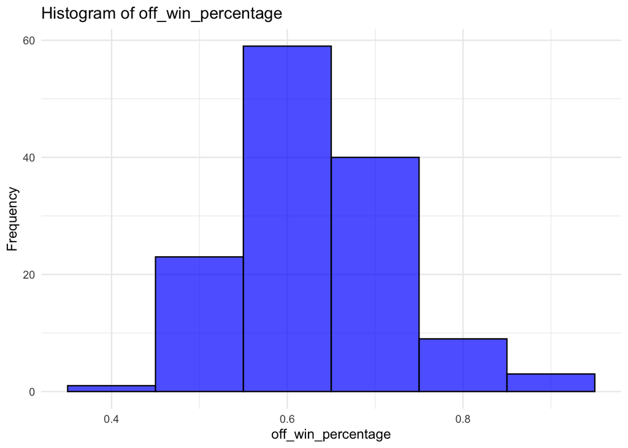

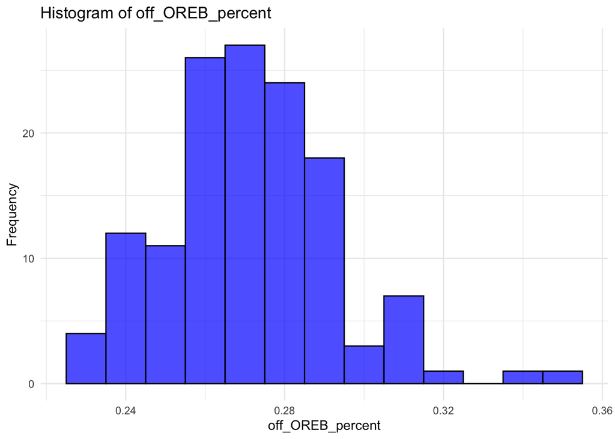

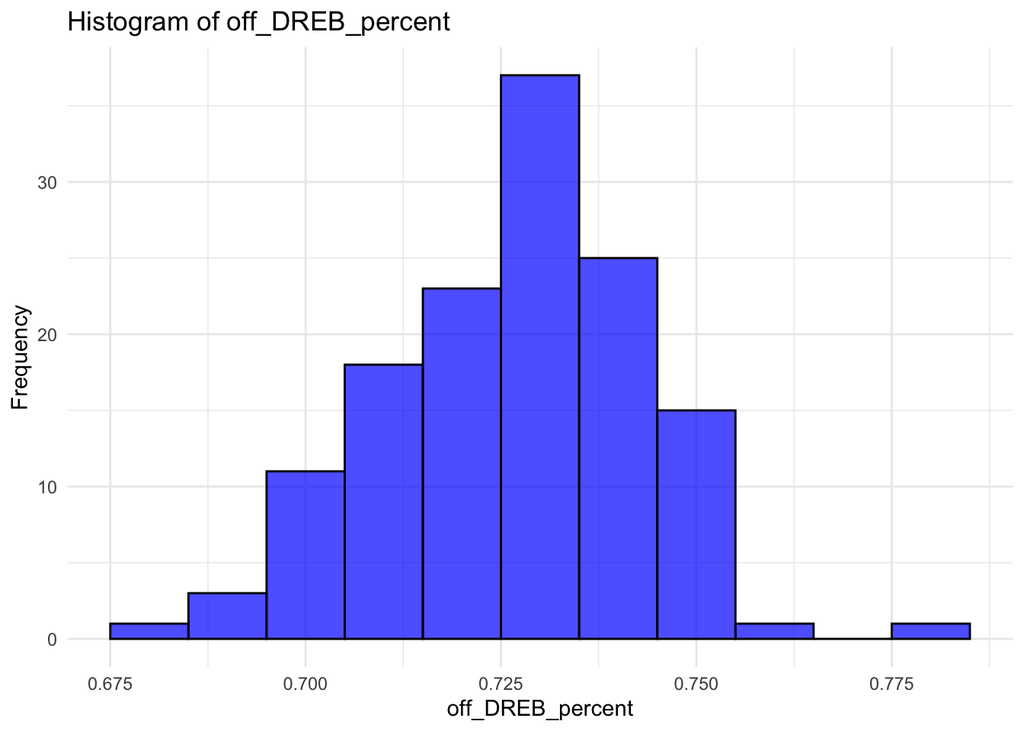

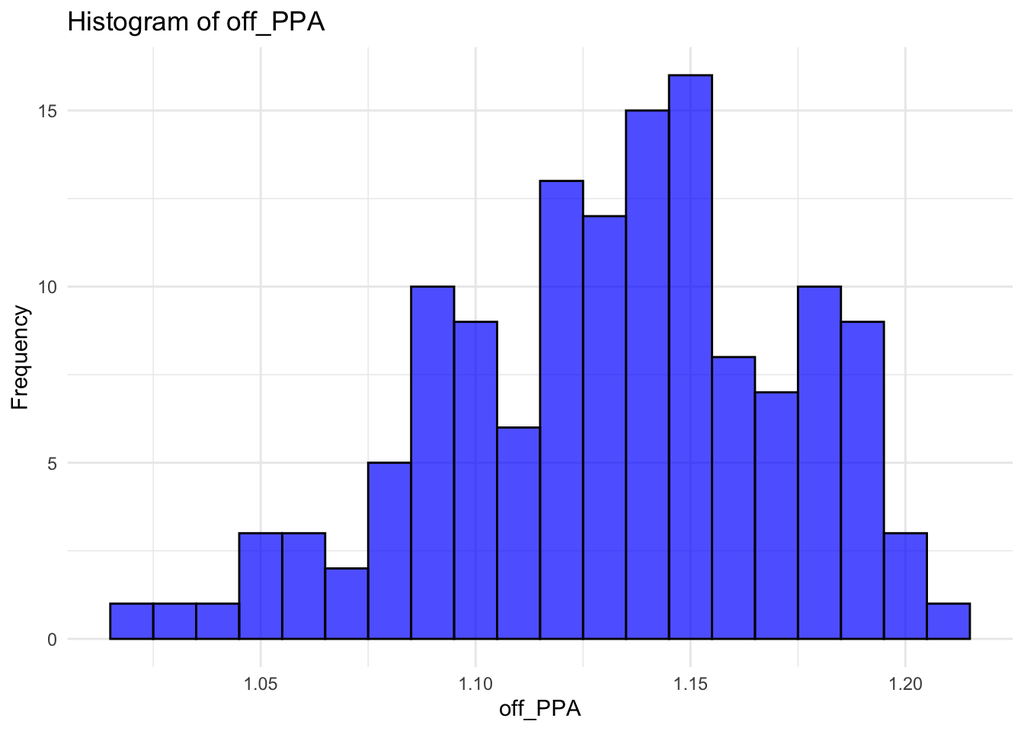

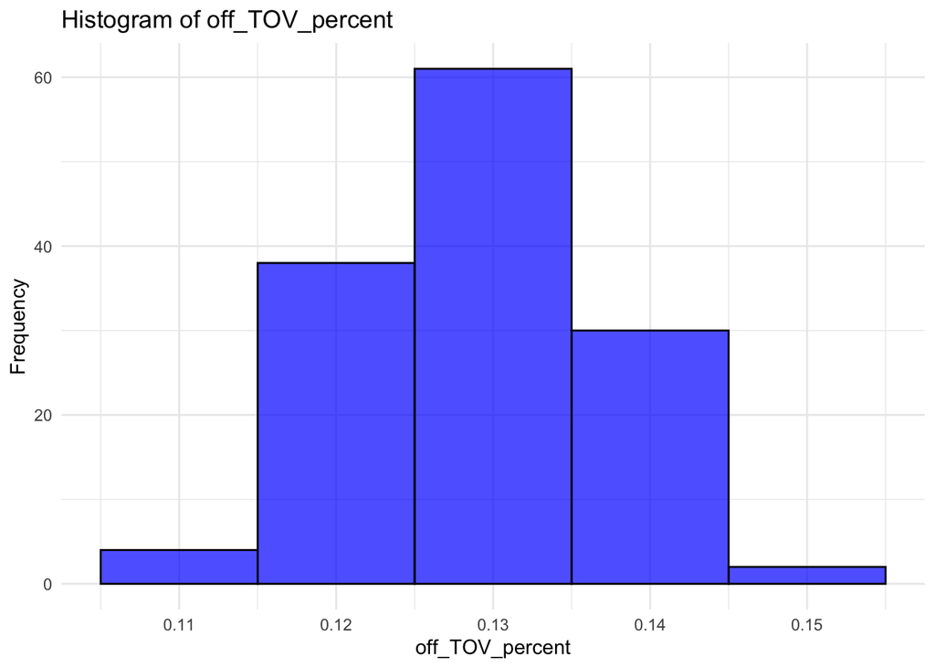

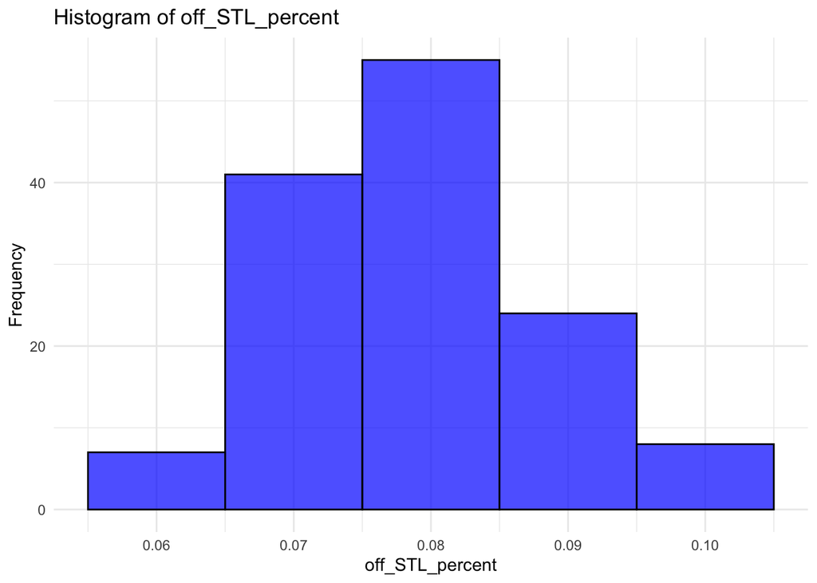

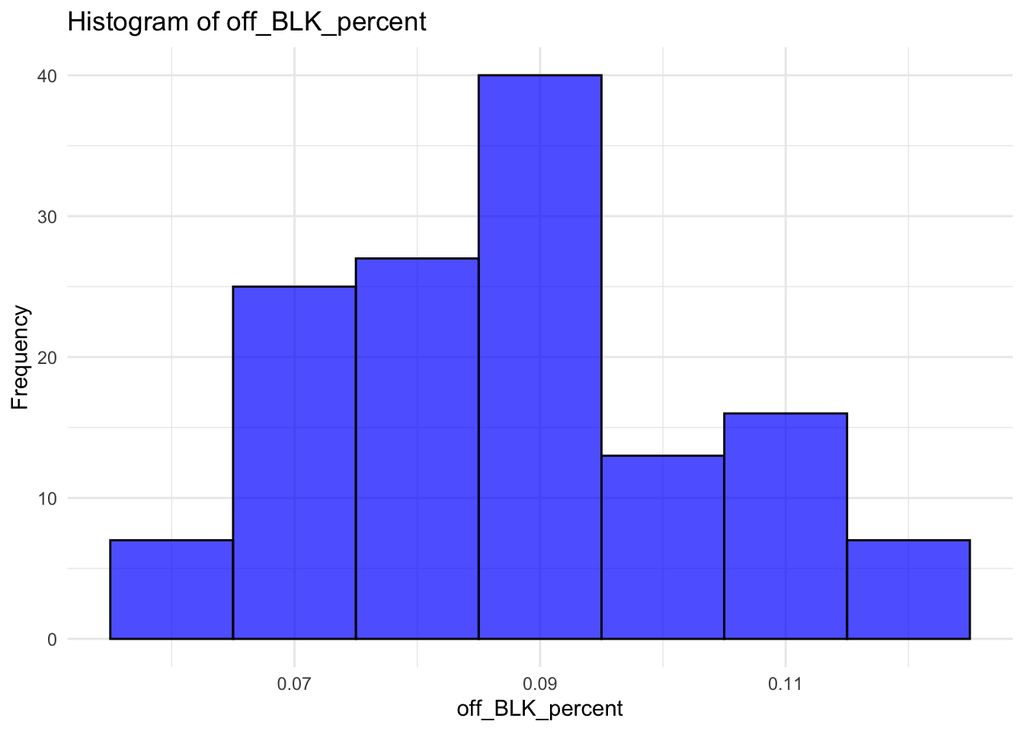

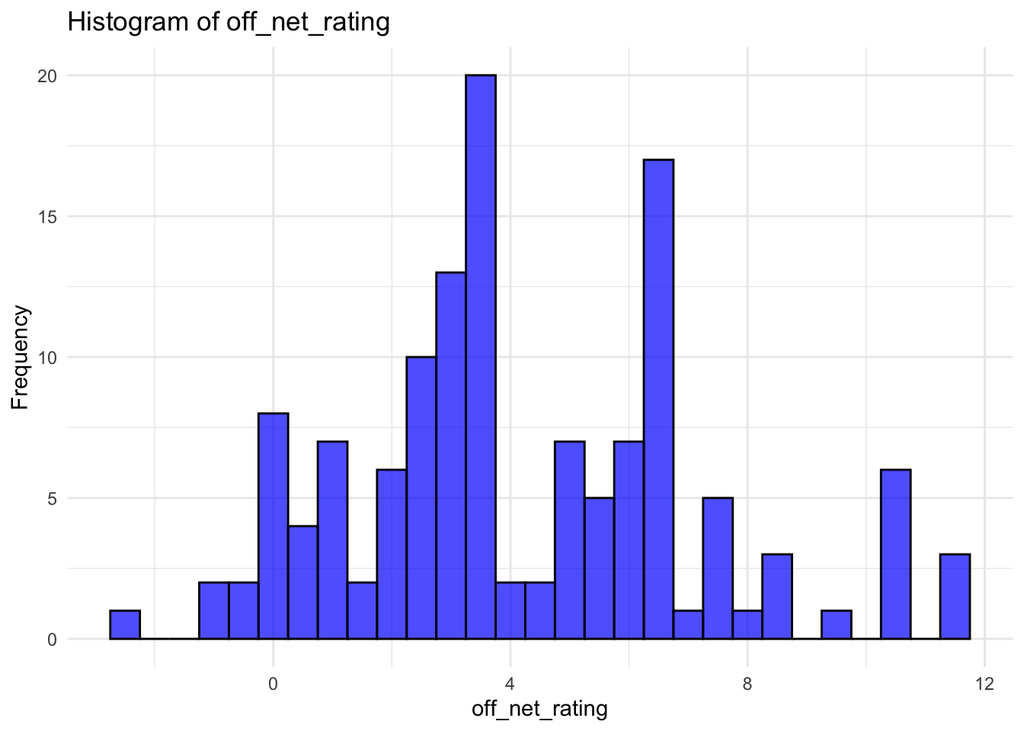

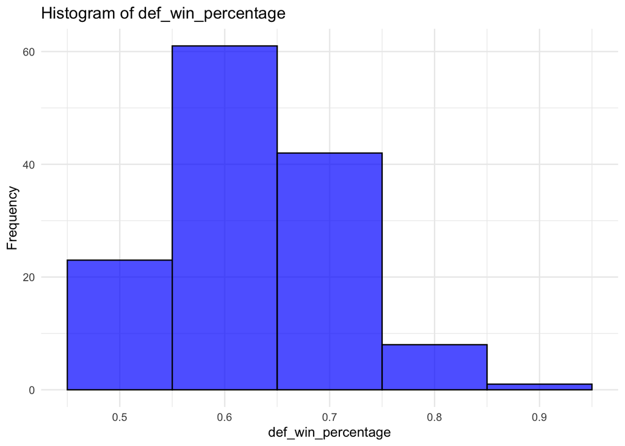

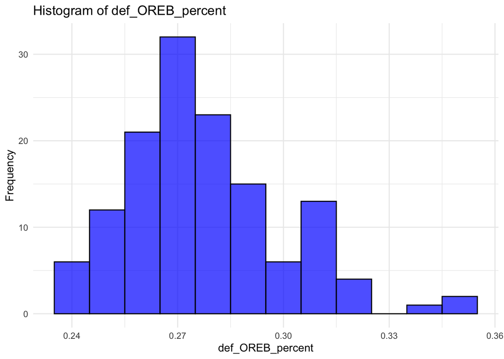

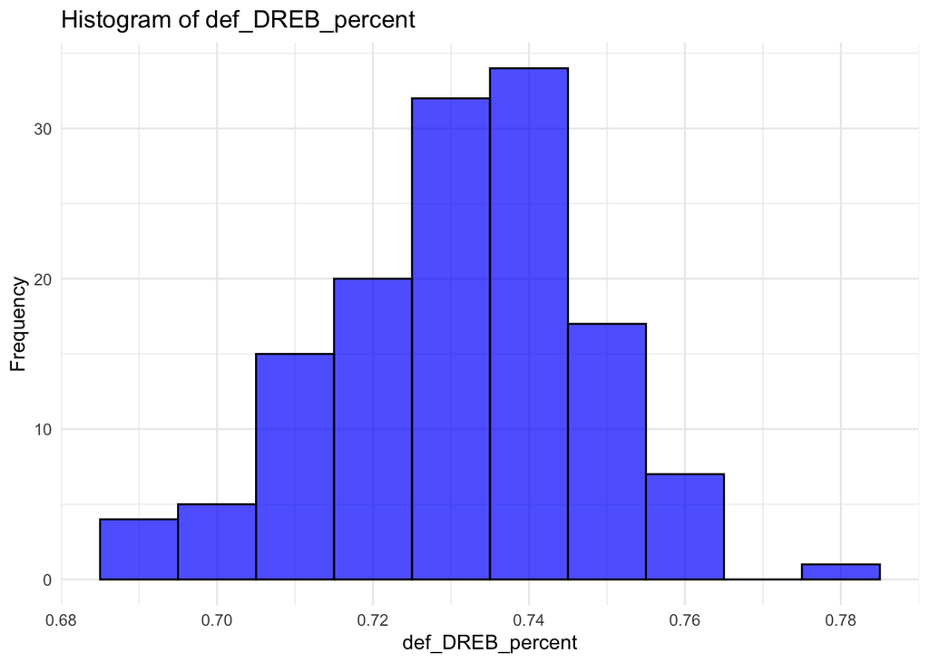

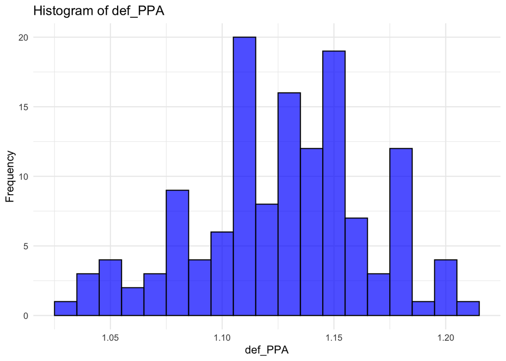

[4 more figures not shown]

```r
col_names <- colnames(team_playoff_features)[-(1:8)]
binwidths <- c(0.1, 0.01, 0.01, 0.01, 0.01, 0.01, 0.01, 0.5, 0.1, 0.01, 0.01, 0.01, 0.01, 0.01, 0.01, 0.5)
for (i in seq_along(col_names)) {
  col <- col_names[i]
  bw <- binwidths[i]
  p <-
    ggplot(team_playoff_features, aes_string(x = col)) +
    geom_histogram(binwidth = bw, fill = "blue", color = "black", alpha = 0.7) +
    labs(title = paste("Histogram of", col), x = col, y = "Frequency") +
    theme_minimal()
    print(p)
}
```

We can scale each feature so that they have zero mean and a standard deviation of one. This will ensure that our model does not place more emphasis on a feature because it is larger in value.

```r
team_playoff_features_scaled <- team_playoff_features
col_names <- colnames(team_playoff_features[-(1:8)])

for (col in col_names) {
  scaled_col <- scale(team_playoff_features_scaled[[col]])
  team_playoff_features_scaled[[col]] <- scaled_col
}
team_playoff_features_scaled
```

```
## # A tibble: 135 × 24
##    season playoff_round off_team_name         def_team_name  off_team_round_wins
##     <dbl>         <dbl> <chr>                 <chr>                        <dbl>
##  1   2014             1 Atlanta Hawks         Brooklyn Nets                    4
##  2   2014             1 Boston Celtics        Cleveland Cav…                   0
##  3   2014             1 Chicago Bulls         Milwaukee Buc…                   4
##  4   2014             1 Dallas Mavericks      Houston Rocke…                   1
##  5   2014             1 Golden State Warriors New Orleans P…                   4
##  6   2014             1 LA Clippers           San Antonio S…                   4
##  7   2014             1 Memphis Grizzlies     Portland Trai…                   4
##  8   2014             1 Toronto Raptors       Washington Wi…                   0
##  9   2014             2 Atlanta Hawks         Washington Wi…                   4
## 10   2014             2 Chicago Bulls         Cleveland Cav…                   2
## # ℹ 125 more rows
## # ℹ 19 more variables: def_team_round_wins <dbl>, off_team_series_win <dbl>,
## #   num_series_games <dbl>, off_win_percentage <dbl[,1]>,
## #   off_OREB_percent <dbl[,1]>, off_DREB_percent <dbl[,1]>, off_PPA <dbl[,1]>,
## #   off_TOV_percent <dbl[,1]>, off_STL_percent <dbl[,1]>,
## #   off_BLK_percent <dbl[,1]>, off_net_rating <dbl[,1]>,
## #   def_win_percentage <dbl[,1]>, def_OREB_percent <dbl[,1]>, …
```

Now that we’ve scaled our feature columns to have zero mean and a standard deviation of one, we can easily plot the distribution of each feature. Our model will also perform better now that each feature is on the same scale. With unscaled features, models will tend to interpret features with larger values as more important, potentially missing the importance of other features.

I’ll now take a look at the cross correlation of each feature with `off_team_win_series` and `num_series_games`

```r
features_and_targets <-
  team_playoff_features_scaled %>%
  select(-c(season, playoff_round, off_team_name, def_team_name,
            off_team_round_wins, def_team_round_wins))

correlation_matrix <- cor(features_and_targets)
cor_with_targets <- correlation_matrix[ , c("off_team_series_win", "num_series_games")]
correlation_tibble <- as_tibble(cor_with_targets, rownames = "Feature")

print(correlation_tibble)
```

```
## # A tibble: 18 × 3
##    Feature             off_team_series_win num_series_games
##    <chr>                             <dbl>            <dbl>
##  1 off_team_series_win              1               0.0852
##  2 num_series_games                 0.0852          1
##  3 off_win_percentage               0.508           0.0190
##  4 off_OREB_percent                 0.0183          0.113
##  5 off_DREB_percent                -0.0210          0.144
##  6 off_PPA                          0.294          -0.0274
##  7 off_TOV_percent                  0.216          -0.0496
##  8 off_STL_percent                  0.168          -0.151
##  9 off_BLK_percent                  0.164           0.00473
## 10 off_net_rating                   0.454           0.0205
## 11 def_win_percentage              -0.323           0.105
## 12 def_OREB_percent                 0.0462         -0.0659
## 13 def_DREB_percent                -0.143          -0.00171
## 14 def_PPA                         -0.265           0.0900
## 15 def_TOV_percent                 -0.0812         -0.0974
## 16 def_STL_percent                  0.0422          0.0738
## 17 def_BLK_percent                 -0.0130         -0.113
## 18 def_net_rating                  -0.318           0.0518
```

Some of these features look fairly promising. Let’s do some training and see how our model does. When splitting the data into training and test, we want to make sure that our model sees data that is representative of an actual post season.

```r
playoff_round_proportions <-
  team_playoff_features_scaled %>%
  group_by(playoff_round) %>%
  summarise(proportion = n() / nrow(team_playoff_features_scaled))
playoff_round_proportions
```

```
## # A tibble: 4 × 2
##   playoff_round proportion
##           <dbl>      <dbl>
## 1             1     0.533
## 2             2     0.267
## 3             3     0.133
## 4             4     0.0667
```

In a post season, there are 8 first round series, 4 second round series, 2 third round series, and 1 fourth round series. That means that ~53% of playoff series are from the 1st round, ~27% are from the 2nd round, ~13% are from the 3rd round, and ~7% are from the the 4th round. We’ll want to make sure that our training data has approximately these percentages of series from each round in it. If there are any patterns that are different from round to round, we’ll want our model to be able to learn those. We’ll also make sure that our training data has series from every year from 2014 - 2022, likewise for our testing data.

```r
team_playoff_features_scaled <-
  team_playoff_features_scaled %>%
  mutate(strata = paste(playoff_round, season, sep = "_"))

n_total_rows <- nrow(team_playoff_features_scaled)
n_train_rows <- round(0.8 * n_total_rows)
n_test_rows <- n_total_rows - n_train_rows

playoff_round_proportions <-
  playoff_round_proportions %>%
   mutate(n_train = round(proportion * n_train_rows),
          n_test = round(proportion * n_test_rows))

set.seed(123)

train_set <- data.frame()
test_set <- data.frame()

for (round in unique(team_playoff_features_scaled$playoff_round)) {
  # Get the required number of samples for this round
  n_train_round <- playoff_round_proportions$n_train[playoff_round_proportions$playoff_round == round]
  n_test_round <- playoff_round_proportions$n_test[playoff_round_proportions$playoff_round == round]

  # Filter the data for this round
  round_data <- team_playoff_features_scaled %>% filter(playoff_round == !!round)

  # Ensure we do not sample more than available
  n_train_round <- min(n_train_round, nrow(round_data))

  # Sample training data
  train_indices <- sample(1:nrow(round_data), n_train_round)
  train_set <- bind_rows(train_set, round_data[train_indices, ])

  # Remaining data after training sampling
  remaining_data <- round_data[-train_indices, ]

  # Ensure we do not sample more than available
  n_test_round <- min(n_test_round, nrow(remaining_data))

  # Sample testing data
  test_indices <- sample(1:nrow(remaining_data), n_test_round)
  test_set <- bind_rows(test_set, remaining_data[test_indices, ])
}

# Verify the stratification by checking the proportions in the training and testing sets
train_proportions <-
  train_set %>%
  count(playoff_round) %>%
  mutate(proportion = n / sum(n))

test_proportions <-
  test_set %>%
  count(playoff_round) %>%
  mutate(proportion = n / sum(n))

print(playoff_round_proportions)
```

```
## # A tibble: 4 × 4
##   playoff_round proportion n_train n_test
##           <dbl>      <dbl>   <dbl>  <dbl>
## 1             1     0.533       58     14
## 2             2     0.267       29      7
## 3             3     0.133       14      4
## 4             4     0.0667       7      2
```

```r
print(train_proportions)
```

```
##   playoff_round  n proportion
## 1             1 58 0.53703704
## 2             2 29 0.26851852
## 3             3 14 0.12962963
## 4             4  7 0.06481481
```

```r
print(test_proportions)
```

```
##   playoff_round  n proportion
## 1             1 14 0.51851852
## 2             2  7 0.25925926
## 3             3  4 0.14814815
## 4             4  2 0.07407407
```

Now that we’ve got our data split and the proportions verified, we can train our model. I’ll separate our training and testing sets into X/Y train/test to be passed to our model.

```r
X_train <- train_set[(9:24)] %>% as.matrix()

X_test <- test_set[(9:24)] %>% as.matrix()

Y_train_classification <- train_set$off_team_series_win
Y_train_regression <- train_set$num_series_games

Y_test_classification <- test_set$off_team_series_win
Y_test_regression <- test_set$num_series_games
```

```r
logistic_model <- glm(Y_train_classification ~ ., data = as.data.frame(X_train), family = binomial)

prediction_classification <- predict(logistic_model, as.data.frame(X_test), type = "response")
predictions_classification_binary <- ifelse(prediction_classification > 0.5, 1, 0)

confusionMatrix(factor(predictions_classification_binary), factor(Y_test_classification))
```

```
## Confusion Matrix and Statistics
##
##           Reference
## Prediction  0  1
##          0  8  6
##          1  3 10
##
##                Accuracy : 0.6667
##                  95% CI : (0.4604, 0.8348)
##     No Information Rate : 0.5926
##     P-Value [Acc > NIR] : 0.2816
##
##                   Kappa : 0.3379
##
##  Mcnemar's Test P-Value : 0.5050
##
##             Sensitivity : 0.7273
##             Specificity : 0.6250
##          Pos Pred Value : 0.5714
##          Neg Pred Value : 0.7692
##              Prevalence : 0.4074
##          Detection Rate : 0.2963
##    Detection Prevalence : 0.5185
##       Balanced Accuracy : 0.6761
##
##        'Positive' Class : 0
##
```

Lets apply some regularization to try and reduce any potential overfitting that may be occurring.

```r
ridge_model_logistic <- cv.glmnet(X_train, Y_train_classification, family = "binomial", alpha = 0)

pred_proba_ridge_logistic <- predict(ridge_model_logistic, newx = as.matrix(X_test), s = "lambda.min", type = "response")
pred_class_ridge_logistic <- ifelse(pred_proba_ridge_logistic > 0.5, 1, 0)

confusion_matrix_ridge <- confusionMatrix(factor(pred_class_ridge_logistic), factor(Y_test_classification))
print(confusion_matrix_ridge)
```

```
## Confusion Matrix and Statistics
##
##           Reference
## Prediction  0  1
##          0  9  4
##          1  2 12
##
##                Accuracy : 0.7778
##                  95% CI : (0.5774, 0.9138)
##     No Information Rate : 0.5926
##     P-Value [Acc > NIR] : 0.03565
##
##                   Kappa : 0.5525
##
##  Mcnemar's Test P-Value : 0.68309
##
##             Sensitivity : 0.8182
##             Specificity : 0.7500
##          Pos Pred Value : 0.6923
##          Neg Pred Value : 0.8571
##              Prevalence : 0.4074
##          Detection Rate : 0.3333
##    Detection Prevalence : 0.4815
##       Balanced Accuracy : 0.7841
##
##        'Positive' Class : 0
##
```

That helped quite a bit. Now to train our linear model.

```r
linear_model <- lm(Y_train_regression ~ ., data = as.data.frame(X_train))

summary(linear_model)
```

```
##
## Call:
## lm(formula = Y_train_regression ~ ., data = as.data.frame(X_train))
##
## Residuals:
##      Min       1Q   Median       3Q      Max
## -2.14190 -0.65144  0.04558  0.79918  1.73859
##
## Coefficients:
##                    Estimate Std. Error t value Pr(>|t|)
## (Intercept)         5.49879    0.09648  56.995   <2e-16 ***
## off_win_percentage  0.12325    0.28288   0.436   0.6641
## off_OREB_percent    0.06426    0.10978   0.585   0.5598
## off_DREB_percent    0.10482    0.13987   0.749   0.4555
## off_PPA            -0.19848    0.17981  -1.104   0.2726
## off_TOV_percent    -0.09597    0.11551  -0.831   0.4083
## off_STL_percent    -0.22460    0.13258  -1.694   0.0937 .
## off_BLK_percent     0.08476    0.13475   0.629   0.5309
## off_net_rating      0.02411    0.29168   0.083   0.9343
## def_win_percentage  0.49946    0.28647   1.744   0.0846 .
## def_OREB_percent   -0.01057    0.13408  -0.079   0.9373
## def_DREB_percent    0.10630    0.14508   0.733   0.4656
## def_PPA             0.11496    0.21114   0.544   0.5874
## def_TOV_percent    -0.20607    0.12312  -1.674   0.0976 .
## def_STL_percent     0.23595    0.13196   1.788   0.0771 .
## def_BLK_percent    -0.19318    0.11284  -1.712   0.0903 .
## def_net_rating     -0.55880    0.32617  -1.713   0.0901 .
## ---
## Signif. codes:  0 '***' 0.001 '**' 0.01 '*' 0.05 '.' 0.1 ' ' 1
##
## Residual standard error: 0.9912 on 91 degrees of freedom
## Multiple R-squared:  0.2087, Adjusted R-squared:  0.0696
## F-statistic:   1.5 on 16 and 91 DF,  p-value: 0.1168
```

```r
predictions_regression <- predict(linear_model, newdata = as.data.frame(X_test))

rmse <- sqrt(mean((predictions_regression - Y_test_regression)^2))
cat("RMSE: ", rmse, "\n")
```

```
## RMSE:  1.191989
```

A RMSE of 1.19 is quite low in this context. Lets see if we get any improvements with regularization.

```r
ridge_model_regression <- cv.glmnet(X_train, Y_train_regression, alpha = 0)

predictions_ridge_regression <- predict(ridge_model_regression, newx = as.matrix(X_test), s = "lambda.min")

rmse_ridge <- sqrt(mean((predictions_ridge_regression - Y_test_regression)^2))
cat("Ridge RMSE: ", rmse_ridge, "\n")
```

```
## Ridge RMSE:  1.089215
```

That seemed to help slightly.

Now that our models are trained, lets take a look at their coefficients to see what the best predictors of series wins and length are.

```r
ridge_coefficients_logistic <- coef(ridge_model_logistic, s = "lambda.min")

print(ridge_coefficients_logistic)
```

```
## 17 x 1 sparse Matrix of class "dgCMatrix"
##                             s1
## (Intercept)         0.29686146
## off_win_percentage  0.60623086
## off_OREB_percent    0.06914761
## off_DREB_percent    0.06826243
## off_PPA             0.34598533
## off_TOV_percent     0.19534291
## off_STL_percent     0.06868631
## off_BLK_percent    -0.12740920
## off_net_rating      0.35459198
## def_win_percentage -0.26456186
## def_OREB_percent   -0.08640944
## def_DREB_percent   -0.04361823
## def_PPA            -0.27759737
## def_TOV_percent    -0.37702644
## def_STL_percent     0.04917452
## def_BLK_percent     0.18131267
## def_net_rating     -0.06852844
```

```r
ridge_coefficients_regression <- coef(ridge_model_regression, s = "lambda.min")

print(ridge_coefficients_regression)
```

```
## 17 x 1 sparse Matrix of class "dgCMatrix"
##                              s1
## (Intercept)         5.498195062
## off_win_percentage  0.005595045
## off_OREB_percent    0.023315464
## off_DREB_percent    0.052001729
## off_PPA            -0.014769899
## off_TOV_percent    -0.032075983
## off_STL_percent    -0.044469920
## off_BLK_percent     0.010910138
## off_net_rating      0.012853676
## def_win_percentage  0.020386363
## def_OREB_percent   -0.035575425
## def_DREB_percent    0.002802126
## def_PPA             0.008074472
## def_TOV_percent    -0.044784294
## def_STL_percent     0.032488314
## def_BLK_percent    -0.038554978
## def_net_rating     -0.008750113
```

Now that we’ve trained and evaluated our models, we can apply them to the 2023 season to predict playoff winners. Lets start by preparing the 2023 regular season team data.

```r
team_data_2023 <- team_data_overall_stats %>% filter(season == 2023)
team_data_2023
```

```
## # A tibble: 30 × 48
##    season team_name               wins losses total_fg2made total_fg2missed
##     <dbl> <chr>                  <dbl>  <dbl>         <dbl>           <dbl>
##  1   2023 Boston Celtics            64     18          2250            1664
##  2   2023 Denver Nuggets            57     25          2652            2067
##  3   2023 Oklahoma City Thunder     57     25          2563            1956
##  4   2023 Minnesota Timberwolves    56     26          2346            1947
##  5   2023 LA Clippers               51     31          2437            1952
##  6   2023 Dallas Mavericks          50     32          2338            1772
##  7   2023 New York Knicks           50     32          2302            2034
##  8   2023 Milwaukee Bucks           49     33          2375            1761
##  9   2023 New Orleans Pelicans      49     33          2461            2031
## 10   2023 Phoenix Suns              49     33          2462            1930
## # ℹ 20 more rows
## # ℹ 42 more variables: total_fg2attempted <dbl>, total_fg3made <dbl>,
## #   total_fg3missed <dbl>, total_fg3attempted <dbl>, total_fgmade <dbl>,
## #   total_fgmissed <dbl>, total_fgattempted <dbl>, total_ftmade <dbl>,
## #   total_ftmissed <dbl>, total_ftattempted <dbl>, total_reboffensive <dbl>,
## #   total_rebdefensive <dbl>, total_offensivereboundchances <dbl>,
## #   total_assists <dbl>, total_stealsagainst <dbl>, total_turnovers <dbl>, …
```

I’ll create a tibble of the teams that made the 2023 season playoffs.

```r
playoff_teams_2023 <-
  tibble(season = 2023,
    team_name = c(
    "Oklahoma City Thunder",
    "New Orleans Pelicans",
    "LA Clippers",
    "Dallas Mavericks",
    "Minnesota Timberwolves",
    "Phoenix Suns",
    "Denver Nuggets",
    "Los Angeles Lakers",
    "Boston Celtics",
    "Miami Heat",
    "Cleveland Cavaliers",
    "Orlando Magic",
    "Milwaukee Bucks",
    "Indiana Pacers",
    "New York Knicks",
    "Philadelphia 76ers"))

playoff_teams_2023
```

```
## # A tibble: 16 × 2
##    season team_name
##     <dbl> <chr>
##  1   2023 Oklahoma City Thunder
##  2   2023 New Orleans Pelicans
##  3   2023 LA Clippers
##  4   2023 Dallas Mavericks
##  5   2023 Minnesota Timberwolves
##  6   2023 Phoenix Suns
##  7   2023 Denver Nuggets
##  8   2023 Los Angeles Lakers
##  9   2023 Boston Celtics
## 10   2023 Miami Heat
## 11   2023 Cleveland Cavaliers
## 12   2023 Orlando Magic
## 13   2023 Milwaukee Bucks
## 14   2023 Indiana Pacers
## 15   2023 New York Knicks
## 16   2023 Philadelphia 76ers
```

Now I’ll create a tibble that contains the matchups in each round of the 2023 season playoffs.

```r
playoffs_2023 <-
  tibble(season = 2023,
         playoff_round = c(rep(1, 8), rep(2, 4), rep(3, 2), 4),
         off_team_name = c("Oklahoma City Thunder", "LA Clippers", "Minnesota Timberwolves", "Denver Nuggets",
                           "Boston Celtics", "Cleveland Cavaliers", "Milwaukee Bucks", "New York Knicks",
                           "Oklahoma City Thunder", "Minnesota Timberwolves",
                           "Boston Celtics", "Indiana Pacers",
                           "Dallas Mavericks",
                           "Boston Celtics",
                           "Dallas Mavericks"),
         def_team_name = c("New Orleans Pelicans", "Dallas Mavericks", "Phoenix Suns", "Los Angeles Lakers",
                           "Miami Heat", "Orlando Magic", "Indiana Pacers", "Philadelphia 76ers",
                           "Dallas Mavericks", "Denver Nuggets",
                           "Cleveland Cavaliers", "New York Knicks",
                           "Minnesota Timberwolves",
                           "Indiana Pacers",
                           "Boston Celtics")
         )

playoffs_2023
```

```
## # A tibble: 15 × 4
##    season playoff_round off_team_name          def_team_name
##     <dbl>         <dbl> <chr>                  <chr>
##  1   2023             1 Oklahoma City Thunder  New Orleans Pelicans
##  2   2023             1 LA Clippers            Dallas Mavericks
##  3   2023             1 Minnesota Timberwolves Phoenix Suns
##  4   2023             1 Denver Nuggets         Los Angeles Lakers
##  5   2023             1 Boston Celtics         Miami Heat
##  6   2023             1 Cleveland Cavaliers    Orlando Magic
##  7   2023             1 Milwaukee Bucks        Indiana Pacers
##  8   2023             1 New York Knicks        Philadelphia 76ers
##  9   2023             2 Oklahoma City Thunder  Dallas Mavericks
## 10   2023             2 Minnesota Timberwolves Denver Nuggets
## 11   2023             2 Boston Celtics         Cleveland Cavaliers
## 12   2023             2 Indiana Pacers         New York Knicks
## 13   2023             3 Dallas Mavericks       Minnesota Timberwolves
## 14   2023             3 Boston Celtics         Indiana Pacers
## 15   2023             4 Dallas Mavericks       Boston Celtics
```

Now that we’ve got the playoff bracket created, lets prepare our X_test matrix by aggregating data from each team’s 2023 regular season.

```r
playoff_teams_data_2023 <-
  inner_join(team_data_2023, playoff_teams_2023, by = "team_name") %>%
  rename(season = season.x) %>%
  select(-c(season.y))

playoff_teams_data_2023
```

```
## # A tibble: 16 × 48
##    season team_name               wins losses total_fg2made total_fg2missed
##     <dbl> <chr>                  <dbl>  <dbl>         <dbl>           <dbl>
##  1   2023 Boston Celtics            64     18          2250            1664
##  2   2023 Denver Nuggets            57     25          2652            2067
##  3   2023 Oklahoma City Thunder     57     25          2563            1956
##  4   2023 Minnesota Timberwolves    56     26          2346            1947
##  5   2023 LA Clippers               51     31          2437            1952
##  6   2023 Dallas Mavericks          50     32          2338            1772
##  7   2023 New York Knicks           50     32          2302            2034
##  8   2023 Milwaukee Bucks           49     33          2375            1761
##  9   2023 New Orleans Pelicans      49     33          2461            2031
## 10   2023 Phoenix Suns              49     33          2462            1930
## 11   2023 Cleveland Cavaliers       48     34          2317            1815
## 12   2023 Indiana Pacers            47     35          2773            1935
## 13   2023 Los Angeles Lakers        47     35          2611            1994
## 14   2023 Orlando Magic             47     35          2415            1981
## 15   2023 Philadelphia 76ers        47     35          2412            2186
## 16   2023 Miami Heat                46     36          2244            2013
## # ℹ 42 more variables: total_fg2attempted <dbl>, total_fg3made <dbl>,
## #   total_fg3missed <dbl>, total_fg3attempted <dbl>, total_fgmade <dbl>,
## #   total_fgmissed <dbl>, total_fgattempted <dbl>, total_ftmade <dbl>,
## #   total_ftmissed <dbl>, total_ftattempted <dbl>, total_reboffensive <dbl>,
## #   total_rebdefensive <dbl>, total_offensivereboundchances <dbl>,
## #   total_assists <dbl>, total_stealsagainst <dbl>, total_turnovers <dbl>,
## #   total_blocksagainst <dbl>, total_defensivefouls <dbl>, …
```

```r
playoff_teams_data_2023 <-
  playoff_teams_data_2023 %>%
  mutate(
    OREB_percent = round(total_reboffensive / total_offensivereboundchances, 4),
    DREB_percent = round(total_defensiverebounds / total_defensivereboundchances, 4),
    PPA = total_shotattemptpoints / total_shotattempts,
    TOV_percent = round(total_turnovers / (total_shotattempts + total_turnovers), 4),
    STL_percent = round(total_steals / total_defensivepossessions, 4),
    BLK_percent = round(total_blocks / total_opponentfg2attempted, 4),
    ORTG = total_points / (total_possessions / 100),
    DRTG = total_pointsagainst / (total_defensivepossessions / 100),
    net_rating = ORTG - DRTG,
    win_percentage = wins / (wins + losses)
  ) %>%
  select(
    season,
    team_name,
    win_percentage,
    OREB_percent,
    DREB_percent,
    TOV_percent,
    STL_percent,
    PPA,
    BLK_percent,
    net_rating
  )

playoff_teams_data_2023
```

```
## # A tibble: 16 × 10
##    season team_name         win_percentage OREB_percent DREB_percent TOV_percent
##     <dbl> <chr>                      <dbl>        <dbl>        <dbl>       <dbl>
##  1   2023 Boston Celtics             0.780        0.287        0.726       0.109
##  2   2023 Denver Nuggets             0.695        0.300        0.718       0.117
##  3   2023 Oklahoma City Th…          0.695        0.250        0.698       0.116
##  4   2023 Minnesota Timber…          0.683        0.275        0.725       0.133
##  5   2023 LA Clippers                0.622        0.283        0.706       0.123
##  6   2023 Dallas Mavericks           0.610        0.257        0.711       0.114
##  7   2023 New York Knicks            0.610        0.333        0.729       0.121
##  8   2023 Milwaukee Bucks            0.598        0.255        0.731       0.118
##  9   2023 New Orleans Peli…          0.598        0.278        0.725       0.120
## 10   2023 Phoenix Suns               0.598        0.292        0.714       0.137
## 11   2023 Cleveland Cavali…          0.585        0.274        0.721       0.126
## 12   2023 Indiana Pacers             0.573        0.284        0.700       0.115
## 13   2023 Los Angeles Lake…          0.573        0.244        0.725       0.128
## 14   2023 Orlando Magic              0.573        0.297        0.737       0.136
## 15   2023 Philadelphia 76e…          0.573        0.292        0.700       0.109
## 16   2023 Miami Heat                 0.561        0.261        0.734       0.120
## # ℹ 4 more variables: STL_percent <dbl>, PPA <dbl>, BLK_percent <dbl>,
## #   net_rating <dbl>
```

Now that the features are created, we can make a row for each game in the playoff series and scale our features.

```r
playoff_stats_2023 <-
  left_join(playoffs_2023, playoff_teams_data_2023, by = c("off_team_name" = "team_name")) %>%
  rename_with(~ paste0("off_", .), -c(playoff_round, off_team_name, def_team_name)) %>%
  select(-c(off_season.x, off_season.y))

playoff_stats_2023
```

```
## # A tibble: 15 × 11
##    playoff_round off_team_name def_team_name off_win_percentage off_OREB_percent
##            <dbl> <chr>         <chr>                      <dbl>            <dbl>
##  1             1 Oklahoma Cit… New Orleans …              0.695            0.250
##  2             1 LA Clippers   Dallas Maver…              0.622            0.283
##  3             1 Minnesota Ti… Phoenix Suns               0.683            0.275
##  4             1 Denver Nugge… Los Angeles …              0.695            0.300
##  5             1 Boston Celti… Miami Heat                 0.780            0.287
##  6             1 Cleveland Ca… Orlando Magic              0.585            0.274
##  7             1 Milwaukee Bu… Indiana Pace…              0.598            0.255
##  8             1 New York Kni… Philadelphia…              0.610            0.333
##  9             2 Oklahoma Cit… Dallas Maver…              0.695            0.250
## 10             2 Minnesota Ti… Denver Nugge…              0.683            0.275
## 11             2 Boston Celti… Cleveland Ca…              0.780            0.287
## 12             2 Indiana Pace… New York Kni…              0.573            0.284
## 13             3 Dallas Maver… Minnesota Ti…              0.610            0.257
## 14             3 Boston Celti… Indiana Pace…              0.780            0.287
## 15             4 Dallas Maver… Boston Celti…              0.610            0.257
## # ℹ 6 more variables: off_DREB_percent <dbl>, off_TOV_percent <dbl>,
## #   off_STL_percent <dbl>, off_PPA <dbl>, off_BLK_percent <dbl>,
## #   off_net_rating <dbl>
```

```r
playoff_stats_2023 <-
  left_join(playoff_stats_2023, playoff_teams_data_2023, by = c("def_team_name" = "team_name")) %>%
  rename_with(~ paste0("def_", .), -c(playoff_round, def_team_name, starts_with("off_"))) %>%
  select(-c(def_season))
playoff_stats_2023
```

```
## # A tibble: 15 × 19
##    playoff_round off_team_name def_team_name off_win_percentage off_OREB_percent
##            <dbl> <chr>         <chr>                      <dbl>            <dbl>
##  1             1 Oklahoma Cit… New Orleans …              0.695            0.250
##  2             1 LA Clippers   Dallas Maver…              0.622            0.283
##  3             1 Minnesota Ti… Phoenix Suns               0.683            0.275
##  4             1 Denver Nugge… Los Angeles …              0.695            0.300
##  5             1 Boston Celti… Miami Heat                 0.780            0.287
##  6             1 Cleveland Ca… Orlando Magic              0.585            0.274
##  7             1 Milwaukee Bu… Indiana Pace…              0.598            0.255
##  8             1 New York Kni… Philadelphia…              0.610            0.333
##  9             2 Oklahoma Cit… Dallas Maver…              0.695            0.250
## 10             2 Minnesota Ti… Denver Nugge…              0.683            0.275
## 11             2 Boston Celti… Cleveland Ca…              0.780            0.287
## 12             2 Indiana Pace… New York Kni…              0.573            0.284
## 13             3 Dallas Maver… Minnesota Ti…              0.610            0.257
## 14             3 Boston Celti… Indiana Pace…              0.780            0.287
## 15             4 Dallas Maver… Boston Celti…              0.610            0.257
## # ℹ 14 more variables: off_DREB_percent <dbl>, off_TOV_percent <dbl>,
## #   off_STL_percent <dbl>, off_PPA <dbl>, off_BLK_percent <dbl>,
## #   off_net_rating <dbl>, def_win_percentage <dbl>, def_OREB_percent <dbl>,
## #   def_DREB_percent <dbl>, def_TOV_percent <dbl>, def_STL_percent <dbl>,
## #   def_PPA <dbl>, def_BLK_percent <dbl>, def_net_rating <dbl>
```

```r
playoff_stats_scaled_2023 <- playoff_stats_2023
col_names_2023 <- colnames(playoff_stats_scaled_2023[-(1:3)])

for (col in col_names_2023) {
    scaled_col <- scale(playoff_stats_2023[[col]])
    playoff_stats_scaled_2023[[col]] <- scaled_col
}

playoff_stats_scaled_2023
```

```
## # A tibble: 15 × 19
##    playoff_round off_team_name          def_team_name     off_win_percentage[,1]
##            <dbl> <chr>                  <chr>                              <dbl>
##  1             1 Oklahoma City Thunder  New Orleans Peli…                  0.392
##  2             1 LA Clippers            Dallas Mavericks                  -0.616
##  3             1 Minnesota Timberwolves Phoenix Suns                       0.224
##  4             1 Denver Nuggets         Los Angeles Lake…                  0.392
##  5             1 Boston Celtics         Miami Heat                         1.57
##  6             1 Cleveland Cavaliers    Orlando Magic                     -1.12
##  7             1 Milwaukee Bucks        Indiana Pacers                    -0.953
##  8             1 New York Knicks        Philadelphia 76e…                 -0.785
##  9             2 Oklahoma City Thunder  Dallas Mavericks                   0.392
## 10             2 Minnesota Timberwolves Denver Nuggets                     0.224
## 11             2 Boston Celtics         Cleveland Cavali…                  1.57
## 12             2 Indiana Pacers         New York Knicks                   -1.29
## 13             3 Dallas Mavericks       Minnesota Timber…                 -0.785
## 14             3 Boston Celtics         Indiana Pacers                     1.57
## 15             4 Dallas Mavericks       Boston Celtics                    -0.785
## # ℹ 15 more variables: off_OREB_percent <dbl[,1]>, off_DREB_percent <dbl[,1]>,
## #   off_TOV_percent <dbl[,1]>, off_STL_percent <dbl[,1]>, off_PPA <dbl[,1]>,
## #   off_BLK_percent <dbl[,1]>, off_net_rating <dbl[,1]>,
## #   def_win_percentage <dbl[,1]>, def_OREB_percent <dbl[,1]>,
## #   def_DREB_percent <dbl[,1]>, def_TOV_percent <dbl[,1]>,
## #   def_STL_percent <dbl[,1]>, def_PPA <dbl[,1]>, def_BLK_percent <dbl[,1]>,
## #   def_net_rating <dbl[,1]>
```

Now that our rows are created and our features scaled, we can create our `X_test_2023` matrix and use our model to predict series outcomes and length.

```r
X_test_2023 <- playoff_stats_scaled_2023[-(1:3)] %>% as.matrix()

pred_proba_ridge_logistic_2023 <- predict(ridge_model_logistic, newx = as.matrix(X_test_2023), s = "lambda.min", type = "response")
pred_class_ridge_logistic_2023 <- ifelse(pred_proba_ridge_logistic_2023 > 0.5, 1, 0)

predictions_ridge_regression_2023 <- predict(ridge_model_regression, newx = as.matrix(X_test_2023), s = "lambda.min")
```

```r
combined_predictions <-
  data.frame(
    off_team_name = playoffs_2023$off_team_name,
    def_team_name = playoffs_2023$def_team_name,
    playoff_round = c(rep(1, 8), rep(2, 4), rep(3, 2), 4),
    probability_off_team_series_win = as.numeric(pred_proba_ridge_logistic_2023),
    predicted_class = as.numeric(pred_class_ridge_logistic_2023),
    predicted_num_series_games = as.numeric(predictions_ridge_regression_2023)
  )

print(combined_predictions)
```

```
##             off_team_name          def_team_name playoff_round
## 1   Oklahoma City Thunder   New Orleans Pelicans             1
## 2             LA Clippers       Dallas Mavericks             1
## 3  Minnesota Timberwolves           Phoenix Suns             1
## 4          Denver Nuggets     Los Angeles Lakers             1
## 5          Boston Celtics             Miami Heat             1
## 6     Cleveland Cavaliers          Orlando Magic             1
## 7         Milwaukee Bucks         Indiana Pacers             1
## 8         New York Knicks     Philadelphia 76ers             1
## 9   Oklahoma City Thunder       Dallas Mavericks             2
## 10 Minnesota Timberwolves         Denver Nuggets             2
## 11         Boston Celtics    Cleveland Cavaliers             2
## 12         Indiana Pacers        New York Knicks             2
## 13       Dallas Mavericks Minnesota Timberwolves             3
## 14         Boston Celtics         Indiana Pacers             3
```

[output cut: 17 more lines]

I’ll create a plot from `combined_predictions` so that we can easily view my model’s predictions for each team in each round.

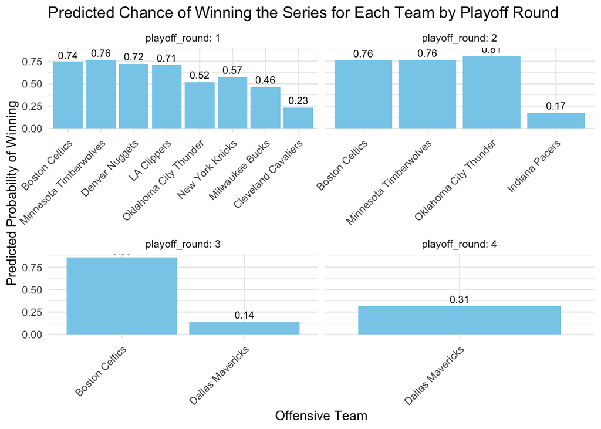

```r
ggplot(combined_predictions, aes(x = reorder(off_team_name, -probability_off_team_series_win), y = probability_off_team_series_win)) +
  geom_bar(stat = "identity", fill = "skyblue") +
  geom_text(aes(label = round(probability_off_team_series_win, 2)), vjust = -0.5, color = "black", size = 3) +
  labs(
    title = "Predicted Chance of Winning the Series for Each Team by Playoff Round",
    x = "Offensive Team",
    y = "Predicted Probability of Winning"
  ) +
  facet_wrap(~ playoff_round, scales = "free_x", labeller = label_both) +
  theme_minimal() +
  theme(axis.text.x = element_text(angle = 45, hjust = 1))
```

The visual above shows the predicted chance of each team labeled the “offensive team” in `combined_predictions` winning their series and advancing to the following round. Their opponent, the “defensive” team, can be found by looking at each row in `combined_predictions`. The odds of the “defensive team” winning is 1 - (odds of “offensive team” winning).

The logistic regression model that I’ve trained essentially learns how important each feature (team statistic) is to winning a playoff series. In the learning process, it is given team data from the 2014 - 2022 regular seasons on each team in the league that made the playoffs that season. It is also given the results of some of the playoff series between two teams. It uses the given data and the results of the series to learn what team statistics best predict a series win. The higher the coefficient on each feature, the more important the model thinks it is.

My linear model, while having a low RMSE, is not especially useful as it predicts a playoff series length of about 5 - 5.5 for each series it is given data on. While this does result in a low RMSE, it is not very insightful. It is likely that other features would be better for predicting series length. The correlation of each feature with series length, examined above, was not strong. With more time, I would explore other features that may be better at predicting series length.

## Part 3 – Finding Insights from Your Model

**ANSWER :**

Find two teams that had a competitive window of 2 or more consecutive seasons making the playoffs and that under performed your model’s expectations for them, losing series they were expected to win. Why do you think that happened? Classify one of them as bad luck and one of them as relating to a cause not currently accounted for in your model. If given more time and data, how would you use what you found to improve your model?

Timberwolves vs. MAVS 2023 season:

Clippers vs. Mavs 2023 season:

With more time, I would try shuffling the offensive and defensive labels, or ensuring that there are a roughly even number of instances in the training data where the “offensive” and “defensive” teams won.